# Proyecto 2

### Integrantes:

- Dayana Valentiana Gonzalez Vargas y Maria Fernanda Rodriguez Conde

### Importación de librarias

```python
 #Importaremos la mayoria de modulos que se utilizaran a lo largo de la práctica

# Modulos basicos
import pandas as pd
import numpy as np
import csv
import seaborn as sns
import matplotlib.pyplot as plt
%matplotlib inline
plt.style.use('seaborn-darkgrid')

# Modulos de scikit-learn
from sklearn.linear_model import LogisticRegression
from sklearn.neighbors import KNeighborsClassifier
from sklearn.metrics import confusion_matrix, classification_report, precision_score, accuracy_score
from sklearn import preprocessing

from sklearn.discriminant_analysis import LinearDiscriminantAnalysis
from sklearn.discriminant_analysis import QuadraticDiscriminantAnalysis
from sklearn.naive_bayes import GaussianNB
from sklearn.metrics import  roc_auc_score, roc_curve, make_scorer, mean_squared_error
from sklearn.inspection import permutation_importance
from sklearn.model_selection import train_test_split
from sklearn.impute import SimpleImputer
from sklearn.mixture import GaussianMixture
from sklearn.preprocessing import StandardScaler
from sklearn.decomposition import KernelPCA
from sklearn.decomposition import FastICA
from sklearn.naive_bayes import GaussianNB
from sklearn.linear_model import LinearRegression, Ridge, RidgeCV, Lasso, LassoCV
from sklearn.pipeline import make_pipeline, Pipeline
from sklearn.decomposition import PCA
from sklearn.feature_selection import SelectKBest
from sklearn.manifold import TSNE
from sklearn.feature_selection import chi2
from sklearn import feature_selection
from sklearn.metrics import r2_score
from sklearn.model_selection import GridSearchCV
from sklearn.ensemble import RandomForestClassifier
from sklearn.metrics import ConfusionMatrixDisplay
from sklearn.model_selection import train_test_split, LeaveOneOut, cross_val_score, cross_val_predict, StratifiedKFold
from sklearn.tree import DecisionTreeClassifier
from sklearn import tree
from sklearn.model_selection import KFold
from sklearn.feature_selection import SelectFromModel
from sklearn.mixture import GaussianMixture
from matplotlib.colors import LogNorm
from sklearn.metrics.cluster import adjusted_rand_score
import graphviz
from sklearn.metrics.cluster import fowlkes_mallows_score

from patsy import dmatrix
from collections import defaultdict
from operator import itemgetter
#Balanceo
from imblearn.over_sampling import SMOTE

# Statmodels
import statsmodels.api as sm
import statsmodels.formula.api as smf
from statsmodels.gam.api import GLMGam, BSplines
```

```python
f= open("risk_factors_cervical_cancer.csv")
reader = csv.reader(f)
```

```python
data = pd.read_csv(f, sep=',', na_values='?')
```

## Análisis exploratorio de datos

Inicialmente observamos la cantidad de datos perdidos con la que cuenta nuestra base de datos para cada una de las variables, donde es necesario hacer una imputación.

```python
data.isna().sum()
```

```
Age                                     0
Number of sexual partners              26
First sexual intercourse                7
Num of pregnancies                     56
Smokes                                 13
Smokes (years)                         13
Smokes (packs/year)                    13
Hormonal Contraceptives               108
Hormonal Contraceptives (years)       108
IUD                                   117
IUD (years)                           117
STDs                                  105
STDs (number)                         105
STDs:condylomatosis                   105
STDs:cervical condylomatosis          105
STDs:vaginal condylomatosis           105
STDs:vulvo-perineal condylomatosis    105
STDs:syphilis                         105
STDs:pelvic inflammatory disease      105
STDs:genital herpes                   105
STDs:molluscum contagiosum            105
STDs:AIDS                             105
STDs:HIV                              105
STDs:Hepatitis B                      105
STDs:HPV                              105
STDs: Number of diagnosis               0
STDs: Time since first diagnosis      787
STDs: Time since last diagnosis       787
Dx:Cancer                               0
Dx:CIN                                  0
Dx:HPV                                  0
Dx                                      0
Hinselmann                              0
Schiller                                0
Citology                                0
Biopsy                                  0
dtype: int64
```

Eliminamos las columnas menos relevantes debido a que tienen muchos valores NaNs o a que representan poca relevancia para los resultados.

```python
del(data['STDs: Time since first diagnosis'])
del(data['STDs: Time since last diagnosis'])
del(data['STDs:AIDS'])
del(data['STDs:cervical condylomatosis'])
```

```python
pd.set_option("max_columns", None)
data
```

|  | Age | Number of sexual partners | First sexual intercourse | Num of pregnancies | Smokes | Smokes (years) | Smokes (packs/year) | Hormonal Contraceptives | Hormonal Contraceptives (years) | IUD | IUD (years) | STDs | STDs (number) | STDs:condylomatosis | STDs:vaginal condylomatosis | STDs:vulvo-perineal condylomatosis | STDs:syphilis | STDs:pelvic inflammatory disease | STDs:genital herpes | STDs:molluscum contagiosum | STDs:HIV | STDs:Hepatitis B | STDs:HPV | STDs: Number of diagnosis | Dx:Cancer | Dx:CIN | Dx:HPV | Dx | Hinselmann | … |
| --- | --- | --- | --- | --- | --- | --- | --- | --- | --- | --- | --- | --- | --- | --- | --- | --- | --- | --- | --- | --- | --- | --- | --- | --- | --- | --- | --- | --- | --- | --- |
| 0 | 18 | 4.0 | 15.0 | 1.0 | 0.0 | 0.0 | 0.0 | 0.0 | 0.00 | 0.0 | 0.0 | 0.0 | 0.0 | 0.0 | 0.0 | 0.0 | 0.0 | 0.0 | 0.0 | 0.0 | 0.0 | 0.0 | 0.0 | 0 | 0 | 0 | 0 | 0 | 0 | … |
| 1 | 15 | 1.0 | 14.0 | 1.0 | 0.0 | 0.0 | 0.0 | 0.0 | 0.00 | 0.0 | 0.0 | 0.0 | 0.0 | 0.0 | 0.0 | 0.0 | 0.0 | 0.0 | 0.0 | 0.0 | 0.0 | 0.0 | 0.0 | 0 | 0 | 0 | 0 | 0 | 0 | … |
| 2 | 34 | 1.0 | NaN | 1.0 | 0.0 | 0.0 | 0.0 | 0.0 | 0.00 | 0.0 | 0.0 | 0.0 | 0.0 | 0.0 | 0.0 | 0.0 | 0.0 | 0.0 | 0.0 | 0.0 | 0.0 | 0.0 | 0.0 | 0 | 0 | 0 | 0 | 0 | 0 | … |
| 3 | 52 | 5.0 | 16.0 | 4.0 | 1.0 | 37.0 | 37.0 | 1.0 | 3.00 | 0.0 | 0.0 | 0.0 | 0.0 | 0.0 | 0.0 | 0.0 | 0.0 | 0.0 | 0.0 | 0.0 | 0.0 | 0.0 | 0.0 | 0 | 1 | 0 | 1 | 0 | 0 | … |
| 4 | 46 | 3.0 | 21.0 | 4.0 | 0.0 | 0.0 | 0.0 | 1.0 | 15.00 | 0.0 | 0.0 | 0.0 | 0.0 | 0.0 | 0.0 | 0.0 | 0.0 | 0.0 | 0.0 | 0.0 | 0.0 | 0.0 | 0.0 | 0 | 0 | 0 | 0 | 0 | 0 | … |
| ... | ... | ... | ... | ... | ... | ... | ... | ... | ... | ... | ... | ... | ... | ... | ... | ... | ... | ... | ... | ... | ... | ... | ... | ... | ... | ... | ... | ... | ... | … |
| 853 | 34 | 3.0 | 18.0 | 0.0 | 0.0 | 0.0 | 0.0 | 0.0 | 0.00 | 0.0 | 0.0 | 0.0 | 0.0 | 0.0 | 0.0 | 0.0 | 0.0 | 0.0 | 0.0 | 0.0 | 0.0 | 0.0 | 0.0 | 0 | 0 | 0 | 0 | 0 | 0 | … |
| 854 | 32 | 2.0 | 19.0 | 1.0 | 0.0 | 0.0 | 0.0 | 1.0 | 8.00 | 0.0 | 0.0 | 0.0 | 0.0 | 0.0 | 0.0 | 0.0 | 0.0 | 0.0 | 0.0 | 0.0 | 0.0 | 0.0 | 0.0 | 0 | 0 | 0 | 0 | 0 | 0 | … |
| 855 | 25 | 2.0 | 17.0 | 0.0 | 0.0 | 0.0 | 0.0 | 1.0 | 0.08 | 0.0 | 0.0 | 0.0 | 0.0 | 0.0 | 0.0 | 0.0 | 0.0 | 0.0 | 0.0 | 0.0 | 0.0 | 0.0 | 0.0 | 0 | 0 | 0 | 0 | 0 | 0 | … |
| 856 | 33 | 2.0 | 24.0 | 2.0 | 0.0 | 0.0 | 0.0 | 1.0 | 0.08 | 0.0 | 0.0 | 0.0 | 0.0 | 0.0 | 0.0 | 0.0 | 0.0 | 0.0 | 0.0 | 0.0 | 0.0 | 0.0 | 0.0 | 0 | 0 | 0 | 0 | 0 | 0 | … |
| 857 | 29 | 2.0 | 20.0 | 1.0 | 0.0 | 0.0 | 0.0 | 1.0 | 0.50 | 0.0 | 0.0 | 0.0 | 0.0 | 0.0 | 0.0 | 0.0 | 0.0 | 0.0 | 0.0 | 0.0 | 0.0 | 0.0 | 0.0 | 0 | 0 | 0 | 0 | 0 | 0 | … |

858 rows × 32 columns

### Desbalanceo de la variable de respuesta

Observamos que nuestra variable respuesta Biopsy esta muy desbalanceada debido a que la cantidad de 0's es 803 y la cantidad de 1's es 55, por lo cual procederemos a hacer una imputacion y utilizaremos el SMOTE para balancear los datos y obtener mejores resultados.

```python
data['Biopsy'].value_counts()
```

```
0    803
1     55
Name: Biopsy, dtype: int64
```

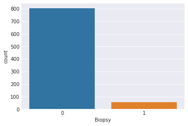

```python
sns.countplot(x='Biopsy',data=data);
```

### Imputación de los datos

Realizamos la imputación, es decir, cambiamos todos los valores de NaNs por la mediana de cada columna, debido a que tambien tenemos variables categoricas en donde la media no sería un buen factor de imputación.

```python
imputer = SimpleImputer(strategy='median')

Newdata = imputer.fit_transform(data) # Ajusta y transforma
print(Newdata)
Newdata2 = pd.DataFrame(Newdata, columns=data.columns)
```

```
[[18.  4. 15. ...  0.  0.  0.]
 [15.  1. 14. ...  0.  0.  0.]
 [34.  1. 17. ...  0.  0.  0.]
 ...
 [25.  2. 17. ...  0.  1.  0.]
 [33.  2. 24. ...  0.  0.  0.]
 [29.  2. 20. ...  0.  0.  0.]]
```

Ahora procedemos a verificar que todos los NaN se hayan eliminado, la sumatoria de NaNs en cada uno debería dar 0:

```python
Newdata2.isna().sum()
```

```
Age                                   0
Number of sexual partners             0
First sexual intercourse              0
Num of pregnancies                    0
Smokes                                0
Smokes (years)                        0
Smokes (packs/year)                   0
Hormonal Contraceptives               0
Hormonal Contraceptives (years)       0
IUD                                   0
IUD (years)                           0
STDs                                  0
STDs (number)                         0
STDs:condylomatosis                   0
STDs:vaginal condylomatosis           0
STDs:vulvo-perineal condylomatosis    0
STDs:syphilis                         0
STDs:pelvic inflammatory disease      0
STDs:genital herpes                   0
STDs:molluscum contagiosum            0
STDs:HIV                              0
STDs:Hepatitis B                      0
STDs:HPV                              0
STDs: Number of diagnosis             0
Dx:Cancer                             0
Dx:CIN                                0
Dx:HPV                                0
Dx                                    0
Hinselmann                            0
Schiller                              0
Citology                              0
Biopsy                                0
dtype: int64
```

#### Matriz de correlación de la base de datos Original.

Encontramos que las variables Dx:Cancer y Dx:HPV estan correlacionadas positivamente, la variable STPs: Número de diagnostico con las variables STDs y STDs: número se encuentran correlacionadas positivamente, la varible STDs:Condylomatosis esta correlacionada posivamente con STDs: número y STDs: vulvo perineal. Por último, nos damos cuenta que las variables que no cuentan con alguna relación son el número de parejas sexuales y la primera relación sexual.

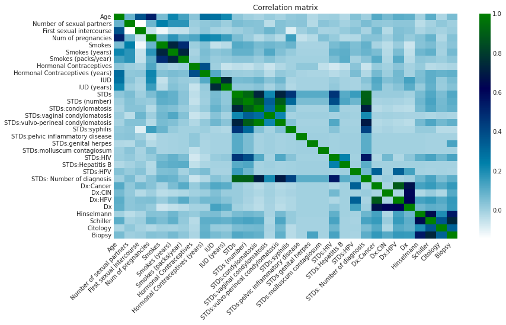

```python
# Grafica de correlación base de datos balanceada
f,ax = plt.subplots(figsize=(13,7))
sns.heatmap(Newdata2.corr(),cmap = 'ocean_r', annot=False, cbar=True )
ax.set_title('Correlation matrix')

ax.set_xticklabels(
    ax.get_xticklabels(),
    rotation = 45,
    horizontalalignment = 'right',
)

ax.tick_params(labelsize = 10)

plt.show()
```

### Diagrama de dispersión

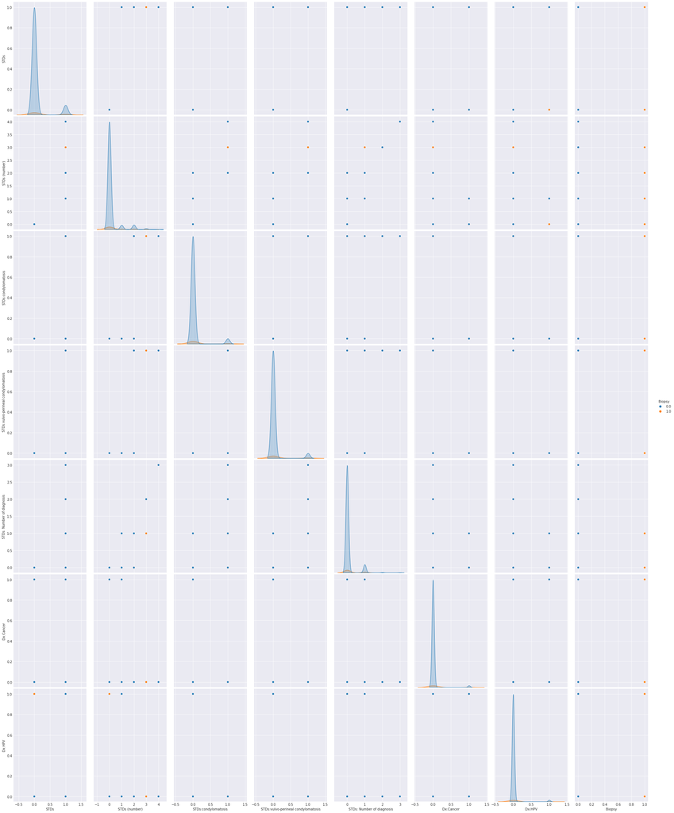

```python
sns.pairplot(Newdata2, x_vars=[ 'STDs', 'STDs (number)', 'STDs:condylomatosis',
         'STDs:vulvo-perineal condylomatosis',
         'STDs: Number of diagnosis',
       'Dx:Cancer',   'Dx:HPV', 'Biopsy'], y_vars=[ 'STDs', 'STDs (number)', 'STDs:condylomatosis',
         'STDs:vulvo-perineal condylomatosis',
         'STDs: Number of diagnosis',
       'Dx:Cancer',   'Dx:HPV'], height=5, aspect=0.7,hue="Biopsy")
plt.show()
```

### Partición de la base de datos (Train y Test)

Se realiza una partición dos dataFrame de entrenamiento y prueba, donde con el de entrenamiento realizaremos un balanceo de la base de datos, recordemos que separaremos un test con 5 filas en donde la variable respuesta Biopsy sea 1.

```python
Newdata_0=[]
Newdata_1=[]
for i in range(len(Newdata2["Biopsy"])):
    if Newdata2["Biopsy"][i]==0:
        Newdata_0.append(Newdata2.iloc[i])
    else:
        Newdata_1.append(Newdata2.iloc[i])

Newdata_0 = pd.DataFrame(Newdata_0, columns=data.columns)
Newdata_1 = pd.DataFrame(Newdata_1, columns=data.columns)
```

```python
#Particion de los datos usando como variable de respuesta Biopsy y como descriptores el resto de la base de datos.
y_0=Newdata_0["Biopsy"]
del(Newdata_0["Biopsy"])
X_0=Newdata_0

y_1=Newdata_1["Biopsy"]
del(Newdata_1["Biopsy"])
X_1=Newdata_1
```

```python
X_train_0, X_test_0, y_train_0, y_test_0 = train_test_split( X_0,y_0, test_size=0.25, random_state=123)
X_train_1, X_test_1, y_train_1, y_test_1 = train_test_split( X_1,y_1, test_size=0.09, random_state=123)
```

```python
len(X_train_1)
```

```
50
```

```python
X_train = []
X_train=X_train_0
X_train=X_train.append(X_train_1,ignore_index=True)

y_train = []
y_train=y_train_0
y_train=y_train.append(y_train_1,ignore_index=True)

X_test = []
X_test=X_test_0
X_test=X_test.append(X_test_1,ignore_index=True)

y_test = []
y_test=y_test_0
y_test=y_test.append(y_test_1,ignore_index=True)
```

### Balanceo (SMOTE)

Realizamos el balanceo teniendo en cuenta que la cantidad de las valores minoritarios de la variable respuesta, en este caso los 1's, deben aumentar hasta cumplir aunque sea el 35% de la cantidad de los 0's.

```python
sm = SMOTE(random_state=42, sampling_strategy=0.35)
X_res1, y_res = sm.fit_resample(X_train, y_train)
X_res = X_res1
```

```python
y_res.value_counts()
```

```
0.0    602
1.0    210
Name: Biopsy, dtype: int64
```

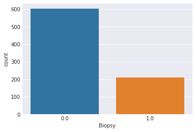

```python
sns.countplot(x=y_res);
```

## Datos Balanceados

Generamos un nuevo dataframe con los datos balanceados para poder realizar un análisis y modelos de clasificación con estos.

```python
X_n= X_res1.assign(Biopsy = y_res)
dft = pd.DataFrame(X_n )
```

### Diagrama de dispersión

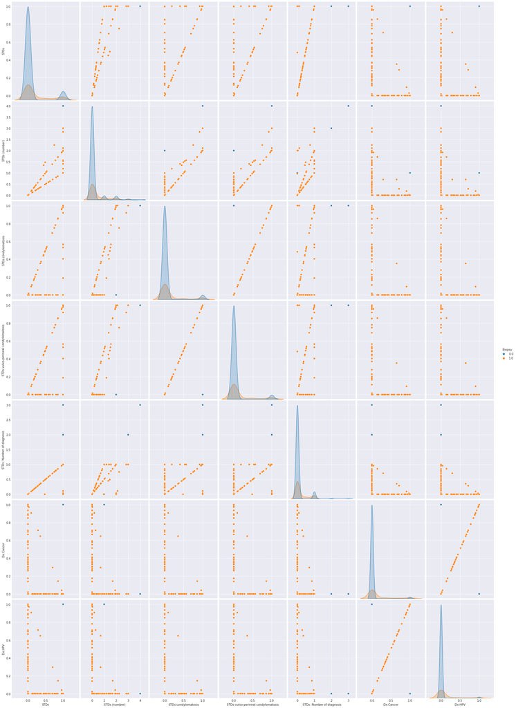

```python
sns.pairplot(dft, x_vars=[ 'STDs', 'STDs (number)', 'STDs:condylomatosis',
         'STDs:vulvo-perineal condylomatosis',
         'STDs: Number of diagnosis',
       'Dx:Cancer',   'Dx:HPV'], y_vars=[ 'STDs', 'STDs (number)', 'STDs:condylomatosis',
         'STDs:vulvo-perineal condylomatosis',
         'STDs: Number of diagnosis',
       'Dx:Cancer',   'Dx:HPV'], height=5, aspect=0.7,hue="Biopsy")
plt.show()
```

```python
dft.describe()
```

|  | Age | Number of sexual partners | First sexual intercourse | Num of pregnancies | Smokes | Smokes (years) | Smokes (packs/year) | Hormonal Contraceptives | Hormonal Contraceptives (years) | IUD | IUD (years) | STDs | STDs (number) | STDs:condylomatosis | STDs:vaginal condylomatosis | STDs:vulvo-perineal condylomatosis | STDs:syphilis | STDs:pelvic inflammatory disease | STDs:genital herpes | STDs:molluscum contagiosum | STDs:HIV | STDs:Hepatitis B | STDs:HPV | STDs: Number of diagnosis | Dx:Cancer | Dx:CIN | Dx:HPV | Dx | Hinselmann | … |
| --- | --- | --- | --- | --- | --- | --- | --- | --- | --- | --- | --- | --- | --- | --- | --- | --- | --- | --- | --- | --- | --- | --- | --- | --- | --- | --- | --- | --- | --- | --- |
| count | 812.000000 | 812.000000 | 812.000000 | 812.000000 | 812.000000 | 812.000000 | 812.000000 | 812.000000 | 812.000000 | 812.000000 | 812.000000 | 812.000000 | 812.000000 | 812.000000 | 812.000000 | 812.000000 | 812.000000 | 812.000000 | 812.000000 | 812.0 | 812.000000 | 812.000000 | 812.000000 | 812.000000 | 812.000000 | 812.000000 | 812.000000 | 812.000000 | 812.000000 | … |
| mean | 27.130226 | 2.528995 | 16.960289 | 2.282025 | 0.149231 | 1.274553 | 0.477396 | 0.678028 | 2.111932 | 0.110290 | 0.465704 | 0.121360 | 0.204021 | 0.068226 | 0.003695 | 0.066995 | 0.019704 | 0.001232 | 0.004050 | 0.0 | 0.037656 | 0.001232 | 0.001232 | 0.113557 | 0.047080 | 0.021029 | 0.045849 | 0.054816 | 0.104130 | … |
| std | 8.490425 | 1.602009 | 2.633068 | 1.349126 | 0.349384 | 4.209454 | 2.257518 | 0.451088 | 3.829778 | 0.301448 | 1.699057 | 0.310384 | 0.568720 | 0.238041 | 0.060708 | 0.235791 | 0.139068 | 0.035093 | 0.051776 | 0.0 | 0.175806 | 0.035093 | 0.035093 | 0.320681 | 0.191325 | 0.129953 | 0.188379 | 0.208359 | 0.276488 | … |
| min | 14.000000 | 1.000000 | 10.000000 | 0.000000 | 0.000000 | 0.000000 | 0.000000 | 0.000000 | 0.000000 | 0.000000 | 0.000000 | 0.000000 | 0.000000 | 0.000000 | 0.000000 | 0.000000 | 0.000000 | 0.000000 | 0.000000 | 0.0 | 0.000000 | 0.000000 | 0.000000 | 0.000000 | 0.000000 | 0.000000 | 0.000000 | 0.000000 | 0.000000 | … |
| 25% | 20.578026 | 2.000000 | 15.000000 | 1.000000 | 0.000000 | 0.000000 | 0.000000 | 0.000000 | 0.000000 | 0.000000 | 0.000000 | 0.000000 | 0.000000 | 0.000000 | 0.000000 | 0.000000 | 0.000000 | 0.000000 | 0.000000 | 0.0 | 0.000000 | 0.000000 | 0.000000 | 0.000000 | 0.000000 | 0.000000 | 0.000000 | 0.000000 | 0.000000 | … |
| 50% | 26.000000 | 2.000000 | 17.000000 | 2.000000 | 0.000000 | 0.000000 | 0.000000 | 1.000000 | 0.500000 | 0.000000 | 0.000000 | 0.000000 | 0.000000 | 0.000000 | 0.000000 | 0.000000 | 0.000000 | 0.000000 | 0.000000 | 0.0 | 0.000000 | 0.000000 | 0.000000 | 0.000000 | 0.000000 | 0.000000 | 0.000000 | 0.000000 | 0.000000 | … |
| 75% | 33.000000 | 3.000000 | 18.000000 | 3.000000 | 0.000000 | 0.000000 | 0.000000 | 1.000000 | 2.000000 | 0.000000 | 0.000000 | 0.000000 | 0.000000 | 0.000000 | 0.000000 | 0.000000 | 0.000000 | 0.000000 | 0.000000 | 0.0 | 0.000000 | 0.000000 | 0.000000 | 0.000000 | 0.000000 | 0.000000 | 0.000000 | 0.000000 | 0.000000 | … |
| max | 84.000000 | 28.000000 | 32.000000 | 11.000000 | 1.000000 | 37.000000 | 37.000000 | 1.000000 | 30.000000 | 1.000000 | 19.000000 | 1.000000 | 4.000000 | 1.000000 | 1.000000 | 1.000000 | 1.000000 | 1.000000 | 1.000000 | 0.0 | 1.000000 | 1.000000 | 1.000000 | 3.000000 | 1.000000 | 1.000000 | 1.000000 | 1.000000 | 1.000000 | … |

## Reducción de la dimensión

#### PCA

Realizaremos una reducción de la dimensión mediante PCA y observaremos como se distribuyen en los componentes principales.

```python
sklearn_pca = PCA(n_components=2)
Y_sklearn = sklearn_pca.fit_transform(X_res)
```

```python
print(sklearn_pca.explained_variance_)
print(sklearn_pca.singular_values_)
```

```
[77.74315876 19.59605951]
[251.0969967  126.06507949]
```

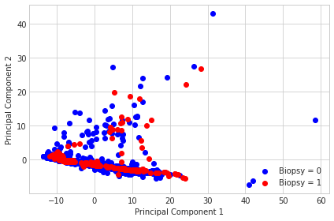

```python
with plt.style.context('seaborn-whitegrid'):
    plt.figure(figsize=(6, 4))
    for lab, col, d in zip((0,1),
                        ('blue', 'red'), ("Biopsy = 0","Biopsy = 1")):
        plt.scatter(Y_sklearn[y_res==lab, 0],
                    Y_sklearn[y_res==lab, 1],
                    label= d,
                    c=col)
    plt.xlabel('Principal Component 1')
    plt.ylabel('Principal Component 2')
    plt.legend(loc='lower right')
    plt.tight_layout()
    plt.show()
```

#### Kernel PCA

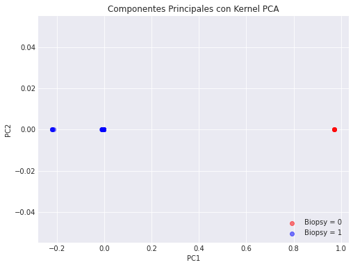

```python
scikit_kpca = KernelPCA(n_components=1, kernel='rbf', gamma=15)
X_skernpca = scikit_kpca.fit_transform(X_res)


plt.figure(figsize=(8,6))
plt.scatter(X_skernpca[y_res ==0, 0], np.zeros((602,1)), color='red', alpha=0.5,label="Biopsy = 0")
plt.scatter(X_skernpca[y_res ==1, 0], np.zeros((210,1)), color='blue', alpha=0.5,label="Biopsy = 1")

#plt.text(-0.38, 0.37, 'gamma = 15', fontsize=12)
plt.title('Componentes Principales con Kernel PCA')
plt.xlabel('PC1')
plt.ylabel('PC2')
plt.legend(loc='lower right')
plt.show()
```

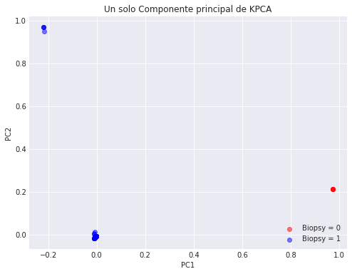

```python
scikit_kpca = KernelPCA(n_components=2, kernel='rbf', gamma=15)
X_skernpca = scikit_kpca.fit_transform(X_res)


plt.figure(figsize=(8,6))
plt.scatter(X_skernpca[y_res ==0, 0], X_skernpca[y_res ==0, 1], color='red', alpha=0.5, label="Biopsy = 0")
plt.scatter(X_skernpca[y_res ==1, 0], X_skernpca[y_res ==1, 1], color='blue', alpha=0.5, label="Biopsy = 1")

#plt.text(-0.38, 0.37, 'gamma = 15', fontsize=12)
plt.title('Un solo Componente principal de KPCA')
plt.xlabel('PC1')
plt.ylabel('PC2')
plt.legend(loc='lower right')
plt.show()
```

#### T-Sne

T-Sne preserva la estructura de datos de cluster, donde según la preplejidad podemos obtener los cluster, si la perplejidad es demasiado alta conduce a la fución de los grupos y si la perplejidad es demasiado pequeña separa los cluster y puede no tener sentido, entonces se debe buscar un número optimo de perplejidad.

```python
tsne = TSNE(n_components=2, verbose=1, random_state=123,perplexity=200,n_iter=1000 )
z = tsne.fit_transform(X_res)
```

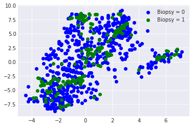

```python
Biopsy_0 = z[y_res ==0]
Biopsy_1 = z[y_res ==1]
plt.scatter(Biopsy_0[:,0], Biopsy_0[:,1], c="b",label="Biopsy = 0")
plt.scatter(Biopsy_1[:,0], Biopsy_1[:,1], c="g",label="Biopsy = 1")
plt.legend()
plt.show()
```

### ICA

En ICA encontramos combinaciones lineales de variables como componentes independientes.

```python
transformer = FastICA(n_components=2,random_state=42)
X_transformed = transformer.fit_transform(X_res)
X_transformed.shape
```

```
(812, 2)
```

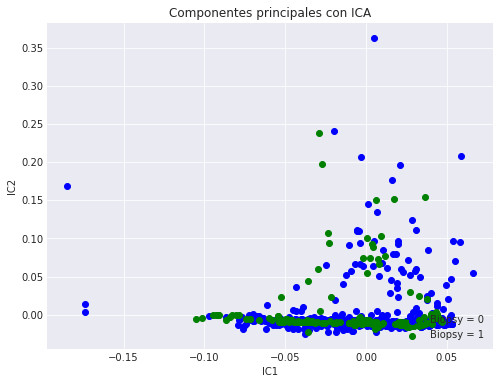

```python
plt.figure(figsize=(8,6))
Biopsy_0 = X_transformed[y_res ==0]
Biopsy_1 = X_transformed[y_res ==1]
plt.scatter(Biopsy_0[:,0], Biopsy_0[:,1], c="b",label="Biopsy = 0")
plt.scatter(Biopsy_1[:,0], Biopsy_1[:,1], c="g",label="Biopsy = 1")
plt.title('Componentes principales con ICA')
plt.xlabel('IC1')
plt.ylabel('IC2')
plt.legend(loc='lower right')
plt.show()
```

# Modelos de clasificación

Definimos la función para generar la matriz de confusión de los siguientes modelos de clasificación o que son utilizados para clasificar según la variable respuesta Biopsy (0: Saludable - No diagnosticado con cancer, 1: Cancer - diagnosticado con cancer)

```python
# Funcion para calcular y visualizar la matriz de confusion
def plotCM(ytrue, ypred, clases=None, normalize = False, ax = None):
    """ Funcion para calcular y visualizar la matriz de confusion"""

    if clases == None:
        clases = list(set(ytrue))
        clases.sort() # etiquetas unicas ordenadas alfabeticamente

    CM = confusion_matrix(ytrue,ypred, labels=clases)

    #Normaliza la matriz de confusion dividiendo cada fila por el total de verdaderos
    if normalize:
        CM = 100*CM / CM.sum(axis=1).reshape(-1,1) #Aprovechando el Broadcasting!

    df = pd.DataFrame(CM, index=clases, columns=clases)
    df.index.name = 'True'; df.columns.name = 'Predicted'

    sns.heatmap( df, # Visualizando la matriz de confusion
             annot=True, fmt='2.1f', cmap='ocean_r',cbar=False,square=True, annot_kws={'fontsize':16}, ax=ax )

    plt.show()
```

# Datos balanceados

## Modelos de clasificación utilizando pipeline, PCA, KPCA e ICA

## PCA

Notemos que según los datos obtenidos anteriormente, tenemos que PCA no muestra una división de los datos notorios, por lo cual utilizaremos un pipeline para encontrar el parámetro adecuado para un clasificador. Además, tomaremos la base de datos balanceada como el _X*train* y _Y*train* .

### Regresión logística con y sin regularización (L1, L2, None)

```python
scale = StandardScaler().fit(X_res)
pca1 = PCA()
logistic = LogisticRegression(max_iter=10000, tol=0.1, solver= 'saga')


pipeline1 = Pipeline(steps=[('pca1', pca1), ('logistic', logistic)])
param_grid = {
    'pca1__n_components': [2, 5, 10, 15, 20],
    'logistic__penalty': ('l1','l2','none')
}
search = GridSearchCV(pipeline1, param_grid)
search_fit = search.fit(X_res,y_res)
```

#### Gráfica componentes principales

Según la gráfica el mejor número de componentes principales para un modelo de regresión logistica en este caso es 15.

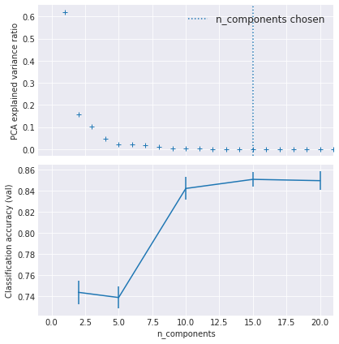

```python
pca1.fit(X_res)

fig, (ax0, ax1) = plt.subplots(nrows=2, sharex=True, figsize=(6, 6))
ax0.plot(np.arange(1, pca1.n_components_ + 1),
         pca1.explained_variance_ratio_, '+', linewidth=2)
ax0.set_ylabel('PCA explained variance ratio')

ax0.axvline(search.best_estimator_.named_steps['pca1'].n_components,
            linestyle=':', label='n_components chosen')
ax0.legend(prop=dict(size=12))

# For each number of components, find the best classifier results
results = pd.DataFrame(search.cv_results_)
components_col = 'param_pca1__n_components'
best_clfs = results.groupby(components_col).apply(
    lambda g: g.nlargest(1, 'mean_test_score'))

best_clfs.plot(x=components_col, y='mean_test_score', yerr='std_test_score',
               legend=False, ax=ax1)
ax1.set_ylabel('Classification accuracy (val)')
ax1.set_xlabel('n_components')

plt.xlim(-1, 21)

plt.tight_layout()
plt.show()
```

#### Tenemos que el mejor modelo de regresion logistica sea L1, L2 o none con su número de componentes óptimo es:

```python
print(search.best_params_)
print("La mejor exactitud (Score): {:.2f}".format(search.best_score_))
```

```
{'logistic__penalty': 'none', 'pca1__n_components': 15}
La mejor exactitud (Score): 0.85
```

#### Matriz de confusión

Notemos de la matriz de confusión nos indica que el 98% de la categoría de sanos esta bien clasificada pero el 2% de esa misma categoría esta mal clasifica como diagnosticados con cancer. Además el 60% de la categoría de diagnosticados con cancer esta mal clasificada como sano pero el 40% si se encuentra bien clasificada en diagnosticados con cancer.

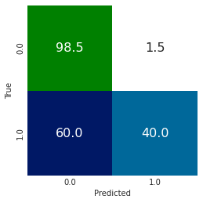

```python
y_pred23 = search.predict(X_test)
plotCM(y_test,y_pred23, normalize=True)
```

Este modelo presenta una exactitud con el test del 97%

```python
print("Exactitud del test es: {:.2f}".format( accuracy_score(y_test,y_pred23) ))
```

```
Exactitud del test es: 0.97
```

#### Validación cruzada y evaluación del modelo con PCA

Mediante validación cruzada encontrarelos el mejor modelo entre (regresión logistica, Analisis de discriminate, NaveBayes, KNN y Randomforest) y veremos las predicciones con respecto a X_test, se esta buscando el que tenga mayor exactitud.

```python
cv = KFold(n_splits=3, shuffle=True, random_state=1)
logistic =LogisticRegression(max_iter=10000, tol=0.1, solver= 'saga')

params = [{'model': [LogisticRegression(max_iter=10000, tol=0.1, solver= 'saga')],
           'model__penalty':('l1','l2','none'),
           'pca1__n_components': [2, 5, 10, 15, 20]},
          {'model': [ LinearDiscriminantAnalysis()],
           'pca1__n_components': [2, 5, 10, 15, 20]},
          {'model': [KNeighborsClassifier()],
           'model__n_neighbors':[2,3,4,8],
           'pca1__n_components': [2, 5, 10, 15, 20]},
           {'model': [GaussianNB()],
           'pca1__n_components': [2, 5, 10, 15, 20]},
           {'model': [RandomForestClassifier()],
           'pca1__n_components': [2, 5, 10, 15, 20]}]

models = [('pca1', pca1), ('model', logistic)]
pipeline4 = Pipeline(steps=models)
search = GridSearchCV(pipeline4, params, scoring='accuracy', n_jobs=-1, cv=cv)
```

```python
search_fit = search.fit(X_res,y_res)
```

#### Análisis de resultados

```python
cv_results = pd.DataFrame(search.cv_results_)
cv_results.iloc[search.best_index_]
```

```
mean_fit_time                                                        0.357138
std_fit_time                                                         0.017461
mean_score_time                                                      0.026113
std_score_time                                                        0.00553
param_model                                          RandomForestClassifier()
param_model__penalty                                                      NaN
param_pca1__n_components                                                   15
param_model__n_neighbors                                                  NaN
params                      {'model': RandomForestClassifier(), 'pca1__n_c...
split0_test_score                                                     0.95572
split1_test_score                                                    0.922509
split2_test_score                                                    0.962963
mean_test_score                                                      0.947064
std_test_score                                                       0.017613
rank_test_score                                                             1
Name: 48, dtype: object
```

```python
print(search.best_params_)
print("La mejor exactitud (Score): {:.2f}".format(search.best_score_))
```

```
{'model': RandomForestClassifier(), 'pca1__n_components': 15}
La mejor exactitud (Score): 0.95
```

#### Matriz de confusión

Evaluaremos ahora las predicciones dadas por el mejor modelo y el conjunto de prueba obteniendo la matriz de confusión para ver que tal es la clasificación.

```python
y_pred21 = search.predict(X_test)
plotCM(y_test,y_pred21, normalize=True)
```

[output not shown]

Notemos a partir de la matriz de confusión que el 98.5% de los datos clasificados en la categoría de sanos (Biopsy = 0) están correctamente clasificados, pero el 1.5% de esta misma clase quedo mal clasificada como de la categoría de diagnosticados con cancer cuando en realidad estan sanos. Tenemos que el 100% de los datos clasificados como diagnosticados con cancer (Biopsy = 1) están correctamente clasificados.

```python
print("Exactitud del test es: {:.2f}".format( accuracy_score(y_test,y_pred21) ))
```

```
Exactitud del test es: 0.99
```

Tenemos que la exactitud dada con el conjunto de prueba es: 99%

Además notemos que es mucho más alta que la obtenida anteriormente con la regresión logistica sin regularización.

## KPCA

Realizamos un pipeline para ver cual kernel es mejor, el número de componentes y con cual modelo de regresión logistica (L1,L2, none), notemos que en las gráficas anteriores se ve una buena división de los datos con tan solo uno o dos componentes, ahora tomaremos más componentes para ver si el modelo puede ser mejor.

```python
scale = StandardScaler().fit(X_res)
kpca1 = KernelPCA(gamma=15)
logistic = LogisticRegression(max_iter=10000, tol=0.1, solver= 'saga')

pipeline2 = Pipeline(steps=[('kpca1', kpca1), ('logistic', logistic)])
param_grid2 = {
    'kpca1__kernel': ('linear', 'poly', 'rbf', 'sigmoid', 'cosine'),
    'kpca1__n_components':[1,2,5],
    'logistic__penalty': ('l1','l2','none')
}
search1 = GridSearchCV(pipeline2, param_grid2)
search1_fit = search1.fit(X_res,y_res)
```

#### Tenemos que el mejor modelo con los siguientes parametros de kernel nos da un mejor valor en el score:

Tenemos que el kpca con un número de componentes de 5 y con su parametro kernel :'rbf' con un modelo de regresión logistica con regularización L1 (Lasso) posee un mayor score que los otros parametros suministrados al pipeline, este tiene una exactitud del 74%.

```python
print(search1.best_params_)
print("La mejor puntuación (Score): {:.2f}".format(search1.best_score_))
```

```
{'kpca1__kernel': 'rbf', 'kpca1__n_components': 5, 'logistic__penalty': 'l1'}
La mejor puntuación (Score): 0.74
```

#### Matriz de confusión

Notemos que a partir de la matriz de confusión tenemos que el 100% se clasificó correctamente como sanos, también el 100% de la categoría diagnosticada con cancer está errónemamente clasificado como sano.

```python
y_pred24 = search1.predict(X_test)
plotCM(y_test,y_pred24,normalize = True)
```

[output not shown]

Tenemos que la exactitud con respecto a el conjunto de prueba es del 98%

```python
print("Exactitud del test es: {:.2f}".format( accuracy_score(y_test,y_pred24) ))
```

```
Exactitud del test es: 0.98
```

#### Validación cruzada y evaluación del modelo con KPCA

Mediante validación cruzada encontraremos el mejor modelo entre (regresión logistica, Analisis de discriminate, NaveBayes, KNN y Randomforest) y veremos las predicciones con respecto a X_test, se esta buscando el que tenga mayor exactitud.

```python
cv = KFold(n_splits=3, shuffle=True, random_state=1)
logistic =LogisticRegression(max_iter=10000, tol=0.1, solver= 'saga')

params = [{'model': [LogisticRegression(max_iter=10000, tol=0.1, solver= 'saga')],
           'model__penalty':('l1','l2','none'),
           'kpca1__n_components': [2, 3,6]},
          {'model': [ LinearDiscriminantAnalysis()],
           'kpca1__n_components': [2, 3,6]},
          {'model': [KNeighborsClassifier()],
           'model__n_neighbors':[2,3,4,8],
           'kpca1__n_components': [2, 3,6]},
           {'model': [GaussianNB()],
           'kpca1__n_components': [2, 3,6]},
           {'model': [RandomForestClassifier()],
           'kpca1__n_components': [2, 3,6]}]

models = [('kpca1', kpca1), ('model', logistic)]
pipeline5 = Pipeline(steps=models)
search1 = GridSearchCV(pipeline5, params, scoring='accuracy', n_jobs=-1, cv=cv)
```

```python
search_fit = search1.fit(X_res,y_res)
```

#### Análisis de resultados

Apartir de los resultados dados a continuación notamos que el mejor modelo con 6 componentes principales fue el randomforest con una exactitud del 84% para esta base de datos balanceada.

```python
cv_results2 = pd.DataFrame(search1.cv_results_)
cv_results2.iloc[search1.best_index_]
```

```
mean_fit_time                                                         0.328268
std_fit_time                                                          0.070563
mean_score_time                                                       0.028246
std_score_time                                                        0.005851
param_kpca1__n_components                                                    6
param_model                                           RandomForestClassifier()
param_model__penalty                                                       NaN
param_model__n_neighbors                                                   NaN
params                       {'kpca1__n_components': 6, 'model': RandomFore...
split0_test_score                                                     0.830258
split1_test_score                                                     0.841328
split2_test_score                                                     0.851852
mean_test_score                                                       0.841146
std_test_score                                                        0.008816
rank_test_score                                                              1
Name: 29, dtype: object
```

```python
print(search1.best_params_)
print("La mejor exactitud (Score): {:.2f}".format(search1.best_score_))
```

```
{'kpca1__n_components': 6, 'model': RandomForestClassifier()}
La mejor exactitud (Score): 0.84
```

#### Matriz de confusión

Evaluaremos ahora las predicciones dadas por el mejor modelo y el conjunto de prueba obteniendo la matriz de confusión para ver que tal es la clasificación.

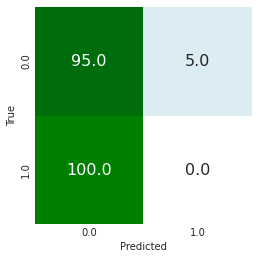

```python
y_pred22 = search1.predict(X_test)
plotCM(y_test,y_pred22, normalize=True)
```

A partir de la matriz de confusión obtenida anteriormente podemos notar que el 95% de la categoria caracterizada como sanos (Biopsy = 0) esta bien clasificada en esa categoría pero el 5 % de la misma esta mal categorizada como diagnosticado con cancer cuando en realidad estan sanos. Para la categoría de diagnosticados con cancer tenemos que el 100% esta categorizado erroneamente como sano cuando no lo es.

```python
print("Exactitud del test es: {:.2f}".format( accuracy_score(y_test,y_pred22) ))
```

```
Exactitud del test es: 0.93
```

Notemos que la exactitud con respecto al conjunto de prueba es del 93%

## ICA

Realizamos un pipeline para observar el mejor numero de componentes posible en un rango de 1 a 20.

```python
scale = StandardScaler().fit(X_res)
ica1 = FastICA(random_state=42)
logistic = LogisticRegression(max_iter=10000, tol=0.1, solver= 'saga')

pipeline3 = Pipeline(steps=[('ica1', ica1), ('logistic', logistic)])
param_grid3 = {
    'ica1__algorithm': ('parallel','deflation'),
    #'ica1__n_components':[1,2,3,4,5,6,7,8,9,10,11,12,13,14,15,16,17,18,19,20] ,
    'ica1__n_components':[1,5,9,13,19] ,
    'ica1__fun' : ('logcosh','exp','cube'),
    'logistic__penalty': ('l1','l2','none')
}
search3 = GridSearchCV(pipeline3, param_grid3)
search3_fit = search3.fit(X_res,y_res)
```

```python
print(search3.best_params_)
print("La mejor puntuación (Score): {:.2f}".format(search3.best_score_))
```

```
{'ica1__algorithm': 'parallel', 'ica1__fun': 'logcosh', 'ica1__n_components': 19, 'logistic__penalty': 'none'}
La mejor puntuación (Score): 0.94
```

#### Matriz de confusión

Tenemos según la matriz de confusión tenemos que el 98% de los clasificados como sanos estas correctamente clasificados pero el 2% están erroneamente clasificados como diagnosticados con cancer, también clasificó correctamente el 100% de la clasificación diagnosticados con cancer.

```python
y_pred25 = search3.predict(X_test)
plotCM(y_test,y_pred25, normalize=True)
```

[output not shown]

La exactitud del modelo es del 98% para el conjunto de prueba

```python
print("Exactitud del test es: {:.2f}".format( accuracy_score(y_test,y_pred25) ))
```

```
Exactitud del test es: 0.98
```

#### Validación cruzada y evaluación del modelo con ICA

Mediante validación cruzada encontraremos el mejor modelo entre (regresión logistica, Analisis de discriminate, NaveBayes, KNN y Randomforest) y veremos las predicciones con respecto a X_test, se esta buscando el que tenga mayor exactitud.

```python
cv = KFold(n_splits=3, shuffle=True, random_state=1)
logistic =LogisticRegression(max_iter=10000, tol=0.1, solver= 'saga')

params = [{'model': [LogisticRegression(max_iter=10000, tol=0.1, solver= 'saga')],
           'model__penalty':('l1','l2','none'),
           'ica1__n_components':[1,5,9,13,19] ,
           'ica1__fun' : ('logcosh','exp','cube')},
          {'model': [ LinearDiscriminantAnalysis()],
           'ica1__n_components':[1,5,9,13,19] ,
            'ica1__fun' : ('logcosh','exp','cube')},
          {'model': [KNeighborsClassifier()],
           'model__n_neighbors':[2,3,4,8],
           'ica1__n_components':[1,5,9,13,19] ,
            'ica1__fun' : ('logcosh','exp','cube')},
           {'model': [GaussianNB()],
           'ica1__n_components':[1,5,9,13,19] ,
            'ica1__fun' : ('logcosh','exp','cube')},
           {'model': [RandomForestClassifier()],
           'ica1__n_components':[1,5,9,13,19] ,
            'ica1__fun' : ('logcosh','exp','cube')}]

models = [('ica1', ica1), ('model', logistic)]
pipeline6 = Pipeline(steps=models)
search4 = GridSearchCV(pipeline6, params, scoring='accuracy', n_jobs=-1, cv=cv)
```

```python
search_fit = search4.fit(X_res,y_res)
```

#### Análisis de resultados

A partir de los resultados notamos que el mejor modelo con 13 componentes y utilizando la funcion exp, fue el de RandomForest, el cual presenta una exactitud del 95% a partir de los datos balanceados.

```python
cv_results3 = pd.DataFrame(search4.cv_results_)
cv_results3.iloc[search4.best_index_]
```

```
mean_fit_time                                                        0.387746
std_fit_time                                                         0.006074
mean_score_time                                                      0.026912
std_score_time                                                       0.005891
param_ica1__fun                                                           exp
param_ica1__n_components                                                   13
param_model                                          RandomForestClassifier()
param_model__penalty                                                      NaN
param_model__n_neighbors                                                  NaN
params                      {'ica1__fun': 'exp', 'ica1__n_components': 13,...
split0_test_score                                                      0.9631
split1_test_score                                                    0.940959
split2_test_score                                                    0.959259
mean_test_score                                                      0.954439
std_test_score                                                        0.00966
rank_test_score                                                             1
Name: 143, dtype: object
```

```python
print(search4.best_params_)
print("La mejor exactitud (Score): {:.2f}".format(search4.best_score_))
```

```
{'ica1__fun': 'exp', 'ica1__n_components': 13, 'model': RandomForestClassifier()}
La mejor exactitud (Score): 0.95
```

#### Matriz de confusión

Evaluaremos las predicciones dadas por el mejor modelo y el conjunto de prueba X_test,y_test realizando la matriz de confusión.

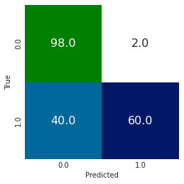

```python
y_pred25 = search4.predict(X_test)
plotCM(y_test,y_pred25, normalize=True)
```

A partir de la matriz de confusión obtenida anteriormente podemos notar que el 98% de la categoría caracterizada como sanos (Biopsy = 0) esta bien clasificada en esa categoría pero el 2% de la misma esta mal categorizada como diagnosticado con cancer cuando en realidad estan sanos. Para la categoría de diagnosticados con cancer tenemos que el 40% esta categorizado erroneamente como sano cuando no lo es, pero un 60% fueron correctamente clasificados en la categoria de (Biopsy = 1)

```python
print("Exactitud del test es: {:.2f}".format( accuracy_score(y_test,y_pred25) ))
```

```
Exactitud del test es: 0.97
```

La exactitud de este modelo respecto al conjunto de prueba es del 97%

## Datos sin reducción de la dimensión

### Regresión logística(Con y sin Regularización L1 y L2)

#### Regresión logistica sin regularización (None)

```python
scaler = preprocessing.StandardScaler().fit(X_res)
lrmodel = LogisticRegression(penalty = 'none', solver= 'lbfgs',max_iter=500)
lrmodel.fit( scaler.transform(X_res),y_res )
y_pred5 = lrmodel.predict( scaler.transform(X_test) )
```

##### Matriz de confusión

A partir de la matriz de confusión nos dimos cuenta que el 97% de la categoría 0's (Biopsia = Falso) está bien clasificado como que en la persona salió negativo en su biopsia, es decir, no esta diagnosticado con cancer, pero el 3% de esa misma categoría está clasificado erroneamente como su biopsia salió positiva, es decir, está diagnosticado con cancer cuando en realidad no. Además, en la categoría de los 1's (Biopsia = True) el modelo clasificó correctamente las 5 filas de la base original que tomamos como test, es decir, que el 100% de esa muestra de test está diagnoticada con cancer.

```python
plotCM(y_test,y_pred5, normalize=True)
```

[output not shown]

##### Exactitud del modelo

El modelo cuenta con una exactitud del 97%

```python
print("Exactitud del test es: {:.2f}".format( accuracy_score(y_test,y_pred5) ))
```

```
Exactitud del test es: 0.97
```

#### Regresión logistica con L2 (Ridge)

```python
scaler = preprocessing.StandardScaler().fit(X_res)
lrmodel = LogisticRegression(solver='lbfgs')
lrmodel.fit( scaler.transform(X_res),y_res )
y_pred1 = lrmodel.predict( scaler.transform(X_test) )
```

##### Matriz de confusión

A partir de la matriz de confusión nos dimos cuenta que el 97% de la categoría 0's (Biopsia = Falso) está bien clasificado como que en la persona salió negativo en su biopsia, es decir, no está diagnosticado con cancer, pero el 3% de esa misma categoría está clasificado erroneamente como su biopsia salió positiva, es decir, está diagnosticado con cancer cuando en realidad no. Además, en la categoría de los 1's (Biopsia = True) el modelo clasificó correctamente las 5 filas de la base original que tomamos como test, es decir, que el 100% de esa muestra de test esta diagnoticada con cancer.

```python
plotCM(y_test,y_pred1, normalize=True)
```

[output not shown]

##### Exactitud del modelo

El modelo cuenta con una exactitud del 97%

```python
print("Exactitud del test es: {:.2f}".format( accuracy_score(y_test,y_pred1) ))
```

```
Exactitud del test es: 0.97
```

### Regresión logística con L1 (Lasso)

```python
scaler = preprocessing.StandardScaler().fit(X_res)
lrmodel = LogisticRegression(penalty='l1',solver='liblinear')
lrmodel.fit( scaler.transform(X_res),y_res )
y_pred3 = lrmodel.predict( scaler.transform(X_test) )
```

**Matriz de confusión**  
A partir de la matriz de confusión nos dimos cuenta que el 97% de la categoría 0's (Biopsia = Falso) está bien clasificado como que en la persona salio negativo en su biopsia, es decir, no esta diagnosticado con cáncer, pero el 3% de esa misma categoría está clasificado erroneamente con cáncer. Además, en la categoría de los 1's (Biopsia = True) el modelo clasificó correctamente las 5 filas de la base original que tomamos como test, es decir, que el 100% de esa muestra de test esta diagnoticada con cáncer.

```python
plotCM(y_test,y_pred3, normalize=True)
```

[output not shown]

**Exactitud del modelo**  
El modelo tuvo una exactitud del 97%, al igual que en las anteriores pruebas de regresión logística.

```python
print("Exactitud del test es: {:.2f}".format( accuracy_score(y_test,y_pred3) ))
```

```
Exactitud del test es: 0.97
```

### Análisis discriminante lineal

```python
model = LinearDiscriminantAnalysis().fit( scaler.transform(X_res), y_res)
y_pred2 = model.predict(scaler.transform(X_test))
```

##### Matriz de confusión

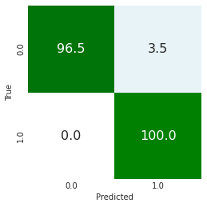

```python
plotCM(y_test,y_pred2, normalize=True)
```

##### La exactitud del modelo

Tenemos que la exactitud dado este modelo el del 97% para los datos balanceados.

```python
print("Exactitud del test es: {:.2f}".format( accuracy_score(y_test,y_pred2) ))
```

```
Exactitud del test es: 0.97
```

### Naive Bayes

```python
gnb = GaussianNB()
gnb.fit(X_res, y_res)
```

```
GaussianNB()
```

```python
y_pred5 = gnb.predict( scaler.transform(X_test))
```

**Matriz de confusión**  
Naive Bayes dió como resultados una clasificación correcta del 100% de personas sanas, es decir con Biopsy = 0, sin embargo tuvo incorrectas a todas las personas con cáncer es decir Biosy = 1, esto nos podría indicar que con esta prueba es muy probable que salgan falsos 0's por lo cual no es muy confiable.

```python
plotCM(y_test, y_pred5,normalize=True)
```

[output not shown]

```python
print("La exactitud (accuracy) de clasificación con el clasificador de NB es:", accuracy_score(y_test,y_pred5))
```

```
La exactitud (accuracy) de clasificación con el clasificador de NB es: 0.9757281553398058
```

### KNN

El número de vecinos que tomamos para realizar el knn fue de 2

```python
scale = StandardScaler().fit(X_res)
knn_model = KNeighborsClassifier(n_neighbors=2) #Instancia al modelo

knn_model.fit( scaler.transform(X_res),y_res) # Ajuste del modelo
y_pred4 = knn_model.predict( scaler.transform(X_test)) # Prediccion
```

#### Matriz de confusión

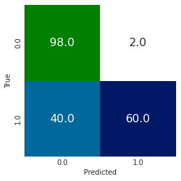

```python
plotCM(y_test, y_pred4,normalize=True) # Matriz de confusion
```

#### Exactitud del modelo

La exactitud de este modelo sigue siendo de un 97% para la base de datos balanceada

```python
print("Exactitud del test es: {:.2f}".format( accuracy_score(y_test,y_pred4) ))
```

```
Exactitud del test es: 0.97
```

### Modelo GLM

```python
#Renombramos las columnas para facilitar el proceso de GLM.
dft2 = dft.rename(columns = {'Number of sexual partners':'Number_of_sexual_partners','First sexual intercourse':'First_sexual_intercourse','Num of pregnancies':'Num_of_pregnancies','Smokes (years)':'Smokes_years','Smokes (packs/year)':'Smokes_packs_per_year','Hormonal Contraceptives':'Hormonal_Contraceptives','Hormonal Contraceptives (years)':'Hormonal_Contraceptives_years','IUD (years)':'IUD_years','STDs (number)':'STDs_number','STDs:condylomatosis':'STDs_condylomatosis','STDs:vaginal condylomatosis':'STDs_vaginal_condylomatosis','STDs:vulvo-perineal condylomatosis':'STDs_vulvo_perineal_condylomatosis','STDs:syphilis':'STDs_syphilis','STDs:pelvic inflammatory disease':'STDs_pelvic_inflammatory_disease','STDs:genital herpes':'STDs_genital_herpes','STDs:molluscum contagiosum':'STDs_molluscum_contagiosum','STDs:HIV':'STDs_HIV','STDs:Hepatitis B':'STDs_Hepatitis_B','STDs:HPV':'STDs_HPV','STDs: Number of diagnosis':'STDs_Number_of_diagnosis','Dx:Cancer':'Dx_Cancer','Dx:CIN':'Dx_CIN','Dx:HPV':'Dx_HPV'})
```

```python
import statsmodels.api as sm
import statsmodels.formula.api as smf
glm1 = smf.glm('Biopsy ~ Number_of_sexual_partners + First_sexual_intercourse + Num_of_pregnancies + Hormonal_Contraceptives + Hormonal_Contraceptives_years', data=dft2,family=sm.families.Poisson(link=sm.families.links.log()))
glm1_res = glm1.fit()
print(glm1_res.summary())
```

```
                 Generalized Linear Model Regression Results
==============================================================================
Dep. Variable:                 Biopsy   No. Observations:                  812
Model:                            GLM   Df Residuals:                      806
Model Family:                 Poisson   Df Model:                            5
Link Function:                    log   Scale:                          1.0000
Method:                          IRLS   Log-Likelihood:                -487.97
Date:                Sat, 16 Oct 2021   Deviance:                       555.94
Time:                        04:46:29   Pearson chi2:                     599.
No. Iterations:                     5   Pseudo R-squ. (CS):            0.01475
Covariance Type:            nonrobust
=================================================================================================
                                    coef    std err          z      P>|z|      [0.025      0.975]
-------------------------------------------------------------------------------------------------
Intercept                        -1.4192      0.508     -2.792      0.005      -2.416      -0.423
Number_of_sexual_partners         0.0151      0.040      0.377      0.706      -0.063       0.093
First_sexual_intercourse          0.0072      0.026      0.272      0.785      -0.044       0.059
Num_of_pregnancies                0.0449      0.050      0.897      0.370      -0.053       0.143
Hormonal_Contraceptives          -0.4638      0.164     -2.836      0.005      -0.784      -0.143
Hormonal_Contraceptives_years     0.0436      0.017      2.606      0.009       0.011       0.076
=================================================================================================
```

```python
glm1 = smf.glm('Biopsy ~ Smokes * Age * Smokes_years + Smokes_packs_per_year', data=dft2,family=sm.families.Poisson(link=sm.families.links.log()))
glm1_res = glm1.fit()
print(glm1_res.summary())
```

```
                 Generalized Linear Model Regression Results
==============================================================================
Dep. Variable:                 Biopsy   No. Observations:                  812
Model:                            GLM   Df Residuals:                      803
Model Family:                 Poisson   Df Model:                            8
Link Function:                    log   Scale:                          1.0000
Method:                          IRLS   Log-Likelihood:                -477.58
Date:                Sat, 16 Oct 2021   Deviance:                       535.16
Time:                        04:46:29   Pearson chi2:                     590.
No. Iterations:                     5   Pseudo R-squ. (CS):            0.03964
Covariance Type:            nonrobust
===========================================================================================
                              coef    std err          z      P>|z|      [0.025      0.975]
-------------------------------------------------------------------------------------------
Intercept                  -2.1176      0.261     -8.127      0.000      -2.628      -1.607
Smokes                     -0.2096      0.993     -0.211      0.833      -2.156       1.737
Age                         0.0264      0.009      3.048      0.002       0.009       0.043
Smokes:Age                 -0.0141      0.034     -0.411      0.681      -0.081       0.053
Smokes_years                5.6898      1.295      4.392      0.000       3.151       8.229
Smokes:Smokes_years        -5.5762      1.277     -4.365      0.000      -8.080      -3.072
Age:Smokes_years           -0.1434      0.037     -3.873      0.000      -0.216      -0.071
Smokes:Age:Smokes_years     0.1420      0.037      3.881      0.000       0.070       0.214
Smokes_packs_per_year      -0.0627      0.054     -1.162      0.245      -0.168       0.043
===========================================================================================
```

Ahora observamos que la interacción entre la prueba DX con DX_CIN fue muy relevante para predecir la Biopsia, con un valor p del 0.007 y la prueba DX_CIN de 0 logró representar gran relevancia de forma individual.

```python
glm2 = smf.glm('Biopsy ~ Dx * Dx_CIN + Dx_Cancer + Dx_HPV', data=dft2,family=sm.families.Poisson(link=sm.families.links.log()))
glm2_res = glm2.fit()
print(glm2_res.summary())
```

```
                 Generalized Linear Model Regression Results
==============================================================================
Dep. Variable:                 Biopsy   No. Observations:                  812
Model:                            GLM   Df Residuals:                      806
Model Family:                 Poisson   Df Model:                            5
Link Function:                    log   Scale:                          1.0000
Method:                          IRLS   Log-Likelihood:                -464.51
Date:                Sat, 16 Oct 2021   Deviance:                       509.02
Time:                        04:46:29   Pearson chi2:                     592.
No. Iterations:                     5   Pseudo R-squ. (CS):            0.07006
Covariance Type:            nonrobust
==============================================================================
                 coef    std err          z      P>|z|      [0.025      0.975]
------------------------------------------------------------------------------
Intercept     -1.5632      0.080    -19.606      0.000      -1.719      -1.407
Dx            -0.1924      0.435     -0.442      0.658      -1.045       0.660
Dx_CIN         5.6209      1.477      3.805      0.000       2.726       8.516
Dx:Dx_CIN     -4.2911      1.597     -2.688      0.007      -7.420      -1.162
Dx_Cancer      0.5936      0.974      0.609      0.542      -1.316       2.504
Dx_HPV         1.0943      0.903      1.212      0.225      -0.675       2.863
==============================================================================
```

Entre las pruebas de Hinselmann, Schiller y Citology, quienes presentaron mayor relevancia en la predicción de la Biopsia fueron la Hinselmann y Schiller junto con su interacción.

```python
glm2 = smf.glm('Biopsy ~ Hinselmann * Schiller + Citology', data=dft2,family=sm.families.Poisson(link=sm.families.links.log()))
glm2_res = glm2.fit()
print(glm2_res.summary())
```

```
                 Generalized Linear Model Regression Results
==============================================================================
Dep. Variable:                 Biopsy   No. Observations:                  812
Model:                            GLM   Df Residuals:                      807
Model Family:                 Poisson   Df Model:                            4
Link Function:                    log   Scale:                          1.0000
Method:                          IRLS   Log-Likelihood:                -308.96
Date:                Sat, 16 Oct 2021   Deviance:                       197.93
Time:                        04:46:29   Pearson chi2:                     463.
No. Iterations:                     7   Pseudo R-squ. (CS):             0.3660
Covariance Type:            nonrobust
=======================================================================================
                          coef    std err          z      P>|z|      [0.025      0.975]
---------------------------------------------------------------------------------------
Intercept              -3.1890      0.197    -16.170      0.000      -3.576      -2.802
Hinselmann              3.6686      0.762      4.815      0.000       2.175       5.162
Schiller                3.0012      0.239     12.580      0.000       2.534       3.469
Hinselmann:Schiller    -3.6533      0.787     -4.642      0.000      -5.196      -2.111
Citology                0.2388      0.180      1.329      0.184      -0.113       0.591
=======================================================================================
```

```python
glm2 = smf.glm('Biopsy ~ STDs * STDs_number + STDs_condylomatosis + STDs_vaginal_condylomatosis + STDs_vulvo_perineal_condylomatosis + STDs_syphilis + STDs_pelvic_inflammatory_disease + STDs_genital_herpes + STDs_molluscum_contagiosum + STDs_HIV + STDs_Hepatitis_B + STDs_Number_of_diagnosis', data=dft2,family=sm.families.Poisson(link=sm.families.links.log()))
glm2_res = glm2.fit()
print(glm2_res.summary())
```

```
                 Generalized Linear Model Regression Results
==============================================================================
Dep. Variable:                 Biopsy   No. Observations:                  812
Model:                            GLM   Df Residuals:                      799
Model Family:                 Poisson   Df Model:                           12
Link Function:                    log   Scale:                          1.0000
Method:                          IRLS   Log-Likelihood:                -457.57
Date:                Sat, 16 Oct 2021   Deviance:                       495.13
Time:                        04:46:29   Pearson chi2:                     571.
No. Iterations:                    21   Pseudo R-squ. (CS):            0.08584
Covariance Type:            nonrobust
======================================================================================================
                                         coef    std err          z      P>|z|      [0.025      0.975]
------------------------------------------------------------------------------------------------------
Intercept                             -1.5589      0.082    -18.956      0.000      -1.720      -1.398
STDs                                   1.8371      0.879      2.090      0.037       0.115       3.560
STDs_number                          -20.4572   6.13e+04     -0.000      1.000    -1.2e+05     1.2e+05
STDs:STDs_number                      -2.8665      0.504     -5.685      0.000      -3.855      -1.878
STDs_condylomatosis                   22.4133   9.68e+04      0.000      1.000    -1.9e+05     1.9e+05
STDs_vaginal_condylomatosis            1.1644    7.5e+04   1.55e-05      1.000   -1.47e+05    1.47e+05
STDs_vulvo_perineal_condylomatosis    23.3237   9.68e+04      0.000      1.000    -1.9e+05     1.9e+05
STDs_syphilis                          0.3318   6.31e+04   5.26e-06      1.000   -1.24e+05    1.24e+05
STDs_pelvic_inflammatory_disease       0.2540   8.66e+04   2.93e-06      1.000    -1.7e+05     1.7e+05
STDs_genital_herpes                   23.4312   6.13e+04      0.000      1.000    -1.2e+05     1.2e+05
STDs_molluscum_contagiosum         -3.944e-14   1.85e-10     -0.000      1.000   -3.64e-10    3.63e-10
STDs_HIV                              22.8474   6.13e+04      0.000      1.000    -1.2e+05     1.2e+05
STDs_Hepatitis_B                       0.7303   8.66e+04   8.43e-06      1.000    -1.7e+05     1.7e+05
STDs_Number_of_diagnosis              -0.2540      0.566     -0.449      0.654      -1.364       0.856
======================================================================================================
```

#### Calculamos el VIF

Definimos la funcion VIF para observar la correlacion de las variables.

```python
def calc_vif(fit):
    """Calcula el VIF para un modelo fit resultado del ajuste de GLM (o OLS)"""

    cov = fit.cov_params() # extrae la covarianza
    corr = cov / fit.bse / fit.bse # Calcula la correlacion con base en los parametros

    vif = pd.Series(np.diag(np.linalg.inv(corr.values[1:, 1:])), index=fit.bse.index[1:])
    vif=abs(vif)
    return(vif)
```

```python
glm5 = smf.glm('Biopsy ~ Hinselmann * Schiller * Citology + Dx * Dx_CIN + Dx_Cancer + Dx_HPV + Smokes * Age * Smokes_years + Smokes_packs_per_year + Number_of_sexual_partners + First_sexual_intercourse + Num_of_pregnancies + Hormonal_Contraceptives + Hormonal_Contraceptives_years + STDs * STDs_number + STDs_condylomatosis + STDs_vaginal_condylomatosis + STDs_vulvo_perineal_condylomatosis + STDs_syphilis + STDs_pelvic_inflammatory_disease + STDs_genital_herpes + STDs_molluscum_contagiosum + STDs_HIV + STDs_Hepatitis_B + STDs_Number_of_diagnosis', data=dft2,family=sm.families.Poisson(link=sm.families.links.log()))
glm5_res = glm5.fit()
calc_vif(glm5_res)
```

```
Hinselmann                            1.377229e+02
Schiller                              2.474087e+00
Hinselmann:Schiller                   1.382517e+02
Citology                              1.074382e+01
Hinselmann:Citology                   2.933821e+02
Schiller:Citology                     1.285067e+01
Hinselmann:Schiller:Citology          2.909677e+02
Dx                                    9.904621e+00
Dx_CIN                                3.026227e+01
Dx:Dx_CIN                             2.386221e+01
Dx_Cancer                             3.307092e+02
Dx_HPV                                3.241136e+02
Smokes                                4.707518e+01
Age                                   3.736276e+00
Smokes:Age                            6.476218e+01
Smokes_years                          1.401168e+04
Smokes:Smokes_years                   1.349269e+04
Age:Smokes_years                      1.841071e+04
Smokes:Age:Smokes_years               1.782459e+04
Smokes_packs_per_year                 2.703764e+00
Number_of_sexual_partners             1.678640e+00
First_sexual_intercourse              1.787726e+00
Num_of_pregnancies                    2.346980e+00
Hormonal_Contraceptives               2.129379e+00
Hormonal_Contraceptives_years         3.662370e+00
STDs                                  3.285995e+01
STDs_number                           7.724167e+12
STDs:STDs_number                      2.643620e+01
STDs_condylomatosis                   1.030581e+14
STDs_vaginal_condylomatosis           6.184725e+13
STDs_vulvo_perineal_condylomatosis    3.373881e+14
STDs_syphilis                         7.165724e+12
STDs_pelvic_inflammatory_disease      6.523820e+12
STDs_genital_herpes                   6.794663e+12
STDs_molluscum_contagiosum            1.091287e+15
STDs_HIV                              6.919402e+12
STDs_Hepatitis_B                      3.225467e+12
STDs_Number_of_diagnosis              1.275956e+01
dtype: float64
```

```python
print(glm5_res.summary())
```

```
                 Generalized Linear Model Regression Results
==============================================================================
Dep. Variable:                 Biopsy   No. Observations:                  812
Model:                            GLM   Df Residuals:                      774
Model Family:                 Poisson   Df Model:                           37
Link Function:                    log   Scale:                          1.0000
Method:                          IRLS   Log-Likelihood:                -278.95
Date:                Sat, 16 Oct 2021   Deviance:                       137.89
Time:                        04:46:30   Pearson chi2:                     220.
No. Iterations:                    22   Pseudo R-squ. (CS):             0.4112
Covariance Type:            nonrobust
======================================================================================================
                                         coef    std err          z      P>|z|      [0.025      0.975]
------------------------------------------------------------------------------------------------------
Intercept                             -3.4363      0.857     -4.008      0.000      -5.117      -1.756
Hinselmann                             1.5854      1.966      0.806      0.420      -2.268       5.438
Schiller                               3.5532      0.337     10.542      0.000       2.893       4.214
Hinselmann:Schiller                   -1.6099      1.978     -0.814      0.416      -5.487       2.268
Citology                               2.2103      0.556      3.977      0.000       1.121       3.300
Hinselmann:Citology                    2.5336      4.885      0.519      0.604      -7.040      12.108
Schiller:Citology                     -1.9271      0.620     -3.109      0.002      -3.142      -0.712
Hinselmann:Schiller:Citology          -2.8346      4.915     -0.577      0.564     -12.469       6.799
Dx                                    -0.6552      0.668     -0.981      0.327      -1.964       0.654
Dx_CIN                                 3.1952      1.726      1.851      0.064      -0.188       6.578
Dx:Dx_CIN                              0.0199      1.732      0.012      0.991      -3.376       3.416
Dx_Cancer                              0.5468      4.177      0.131      0.896      -7.639       8.733
Dx_HPV                                 0.1271      4.135      0.031      0.975      -7.977       8.231
Smokes                                -0.4068      1.474     -0.276      0.783      -3.296       2.483
Age                                   -0.0237      0.016     -1.492      0.136      -0.055       0.007
Smokes:Age                            -0.0103      0.054     -0.190      0.849      -0.116       0.096
Smokes_years                           4.9961      1.768      2.826      0.005       1.531       8.462
Smokes:Smokes_years                   -4.8171      1.742     -2.765      0.006      -8.232      -1.402
Age:Smokes_years                      -0.1352      0.050     -2.722      0.006      -0.233      -0.038
Smokes:Age:Smokes_years                0.1324      0.049      2.700      0.007       0.036       0.229
Smokes_packs_per_year                 -0.0187      0.065     -0.287      0.774      -0.146       0.109
Number_of_sexual_partners              0.0634      0.069      0.919      0.358      -0.072       0.198
First_sexual_intercourse              -0.0230      0.049     -0.466      0.641      -0.120       0.074
Num_of_pregnancies                     0.1554      0.087      1.788      0.074      -0.015       0.326
Hormonal_Contraceptives                0.2852      0.232      1.230      0.219      -0.169       0.740
Hormonal_Contraceptives_years         -0.0111      0.028     -0.390      0.696      -0.067       0.045
STDs                                  -0.5254      1.091     -0.482      0.630      -2.663       1.613
STDs_number                          -20.1177   1.01e+05     -0.000      1.000   -1.98e+05    1.98e+05
STDs:STDs_number                      -0.2876      0.563     -0.511      0.610      -1.392       0.816
STDs_condylomatosis                   21.2245    1.6e+05      0.000      1.000   -3.13e+05    3.13e+05
STDs_vaginal_condylomatosis           -0.2483   1.24e+05  -2.01e-06      1.000   -2.42e+05    2.42e+05
STDs_vulvo_perineal_condylomatosis    20.5231    1.6e+05      0.000      1.000   -3.13e+05    3.13e+05
STDs_syphilis                         -0.6980   1.03e+05   -6.8e-06      1.000   -2.01e+05    2.01e+05
STDs_pelvic_inflammatory_disease       1.0353   1.43e+05   7.25e-06      1.000    -2.8e+05     2.8e+05
STDs_genital_herpes                   23.8735   1.01e+05      0.000      1.000   -1.98e+05    1.98e+05
STDs_molluscum_contagiosum         -7.782e-15   9.83e-11  -7.91e-05      1.000   -1.93e-10    1.93e-10
STDs_HIV                              19.7657   1.01e+05      0.000      1.000   -1.98e+05    1.98e+05
STDs_Hepatitis_B                       0.7733   1.43e+05   5.41e-06      1.000    -2.8e+05     2.8e+05
STDs_Number_of_diagnosis              -0.0710      0.702     -0.101      0.919      -1.446       1.304
======================================================================================================
```

### Arboles de decisión

Realizaremos un arbol de decisión

```python
clf = DecisionTreeClassifier(max_depth=None, max_leaf_nodes=6, max_features=3)
clf1 = clf.fit(X_res,y_res)
```

```python
dot_data = tree.export_graphviz(clf, out_file=None,
                        feature_names=X_res.columns,
                        class_names= "Biopsy",
                         filled=True, rounded=True,
                         special_characters=True)
graph = graphviz.Source(dot_data)
graph
```

[figure not shown]

#### Matriz de confusión de la clasificación por árboles de desición

Mediante el arbol de confunsión obtuvimos que el 95.5% de la categoría de 0's fue bien clasificada pero un 4.5% estuvo mal clasificado como de la categoría de los 1's.Para la categoría de los 1's tenemos que 100% estuvo bien clasificado como diagnosticado con cancer.

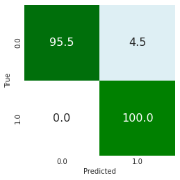

```python
y_pred11 = clf.predict(X_test)
plotCM(y_test, y_pred11,normalize=True) # Matriz de confusion
```

#### Exactitud del modelo de arboles de clasificación

A pesar de lo dado en la matriz de confusión tenemos que la exactitud con respecto al test fue del 96%

```python
print("Exactitud del test es: {:.2f}".format( accuracy_score(y_test,y_pred11) ))
```

```
Exactitud del test es: 0.96
```

### Gaussiano Mixture

```python
scale = StandardScaler().fit(X_res)
gmm = GaussianMixture( random_state=2)
#gmm.fit(X_res,y_res)
pipeline14 = Pipeline(steps=[('gmm', gmm)])
param_grid = {
    'gmm__n_components': [1,2,3,4,5],
    'gmm__covariance_type': ('full', 'tied', 'diag', 'spherical')
}
search8 = GridSearchCV(pipeline14, param_grid,scoring='adjusted_rand_score',cv =cv)
search8_fit = search8.fit(X_res,y_res)
```

```python
print(search8.best_params_)
print("La metrica Ari con Train(Score): {:.2f}".format(search8.best_score_))
```

```
{'gmm__covariance_type': 'diag', 'gmm__n_components': 3}
La metrica Ari con Train(Score): 0.25
```

### Metrica (ARI)

Tenemos que es una metrica entre -1 y 1, donde si se tiene un Ari muy cercano a 0 son etiquetas aleatorias y si es cercano a 1 tenemos que coinciden perfectamente.

```python
#y_pred31 = search8.predict(X_test)
y_pred31 = search8.predict(X_test)
metrica_ari = adjusted_rand_score(y_test,y_pred31)
print("Metrica ari: {:.2f}".format( metrica_ari ))
```

```
Metrica ari: -0.01
```

La metrica ari para el conjunto de prueba es de casi 0 lo que significa que las clases estan completamente divididos en los clustering, lo cual puede llegar a ser incompleto.

### Metrica Fowlkes_ Mallowas

según esta metrica tenemos que los valores van entre 0 y 1. Donde entre más cercano hay una buena similitud entre los clustering.

```python
metrica_fow = fowlkes_mallows_score(y_test,y_pred31)
print("Metrica fowlkes_mallows : {:.2f}".format( metrica_fow ))
```

```
Metrica fowlkes_mallows : 0.74
```

Obtuvimos según esta metrica que hay una buena similitud entre los cluster aunque no es perfecta, la metrica dio 0.74.

# Datos no balanceados

### PCA

Mediante validacion cruzada y pipeline encontraremos el mejor modelo entre regresión logistica, análisis de discriminante, Naive Bayes, KNN y Randomforest utilizando nuestros datos no balanceados X_train y y_train, así obtendremos el modelo con el que estos datos presentan una mayor exactitud en PCA.

```python
scale = StandardScaler().fit(X_train)
pca2 = PCA()
cv = KFold(n_splits=3, shuffle=True, random_state=1)
logistic =LogisticRegression(max_iter=10000, tol=0.1, solver= 'saga')

params = [{'model': [LogisticRegression(max_iter=10000, tol=0.1, solver= 'saga')],
           'model__penalty':('l1','l2','none'),
           'pca2__n_components': [2, 5, 10, 15, 20]},
          {'model': [ LinearDiscriminantAnalysis()],
           'pca2__n_components': [2, 5, 10, 15, 20]},
          {'model': [KNeighborsClassifier()],
           'model__n_neighbors':[2,3,4,8],
           'pca2__n_components': [2, 5, 10, 15, 20]},
           {'model': [GaussianNB()],
           'pca2__n_components': [2, 5, 10, 15, 20]},
           {'model': [RandomForestClassifier()],
           'pca2__n_components': [2, 5, 10, 15, 20]}]

models = [('pca2', pca2), ('model', logistic)]
pipeline10 = Pipeline(steps=models)
search10 = GridSearchCV(pipeline10, params, scoring='accuracy', n_jobs=-1, cv=cv)
search_fit = search10.fit(X_train,y_train)
```

#### Análisis de resultados

A partir de los resultados obtuvimos que el mejor modelo con 20 componentes principales fue el de analisis discriminante lineal con una exactitud del 95%, utilizando los datos no balanceados.

```python
cv_results10 = pd.DataFrame(search10.cv_results_)
cv_results10.iloc[search10.best_index_]
```

```
mean_fit_time                                                         0.00916
std_fit_time                                                         0.000541
mean_score_time                                                      0.003701
std_score_time                                                       0.000461
param_model                                      LinearDiscriminantAnalysis()
param_model__penalty                                                      NaN
param_pca2__n_components                                                   20
param_model__n_neighbors                                                  NaN
params                      {'model': LinearDiscriminantAnalysis(), 'pca2_...
split0_test_score                                                    0.981651
split1_test_score                                                    0.953917
split2_test_score                                                    0.930876
mean_test_score                                                      0.955481
std_test_score                                                       0.020759
rank_test_score                                                             1
Name: 19, dtype: object
```

```python
print(search10.best_params_)
print("La mejor exactitud (Score): {:.2f}".format(search.best_score_))
```

```
{'model': LinearDiscriminantAnalysis(), 'pca2__n_components': 20}
La mejor exactitud (Score): 0.95
```

#### Matriz de confusión

Evaluamos las predicciones dadas por el mejor modelo obtenido con nuestro conjunto de prueba.

```python
y_pred50 = search.predict(X_test)
plotCM(y_test,y_pred50, normalize=True)
```

[output not shown]

Notamos que el 98.5% de los datos clasificados en la categoría sanos, es decir Biopsy = 0, están correctamente clasificados, con tan solo un 1.5% de datos mal clasificados con cancer. Por otro lado, el 100% de los casos diagnosticado con cancer, es decir Biopsy = 1, están correctamente clasificados.

```python
print("Exactitud del test es: {:.2f}".format( accuracy_score(y_test,y_pred50) ))
```

```
Exactitud del test es: 0.99
```

La exactitud dada con el conjunto de prueba es del 99%, la cual es muy similar a la que se presentaba con los datos balanceados (99%).

### KPCA

Mediante validacion cruzada y pipeline encontraremos el mejor modelo entre regresión logística, análisis de discriminante, Naive Bayes, KNN y Randomforest, utilizando nuestros datos no balanceados X_train y y_train, así obtendremos el modelo con el que estos datos presentan una mayor exactitud en KPCA.

```python
scale = StandardScaler().fit(X_train)
kpca2 = KernelPCA(gamma=15)
cv = KFold(n_splits=3, shuffle=True, random_state=1)
logistic =LogisticRegression(max_iter=10000, tol=0.1, solver= 'saga')

params = [{'model': [LogisticRegression(max_iter=10000, tol=0.1, solver= 'saga')],
           'model__penalty':('l1','l2','none'),
           'kpca2__n_components': [2, 3,6]},
          {'model': [ LinearDiscriminantAnalysis()],
           'kpca2__n_components': [2, 3,6]},
          {'model': [KNeighborsClassifier()],
           'model__n_neighbors':[2,3,4,8],
           'kpca2__n_components': [2, 3,6]},
           {'model': [GaussianNB()],
           'kpca2__n_components': [2, 3,6]},
           {'model': [RandomForestClassifier()],
           'kpca2__n_components': [2, 3,6]}]

models = [('kpca2', kpca2), ('model', logistic)]
pipeline11 = Pipeline(steps=models)
search11 = GridSearchCV(pipeline11, params, scoring='accuracy', n_jobs=-1, cv=cv)
search_fit = search11.fit(X_train,y_train)
```

#### Análisis de resultados

```python
cv_results11 = pd.DataFrame(search11.cv_results_)
cv_results11.iloc[search11.best_index_]
```

```
mean_fit_time                                                         0.016118
std_fit_time                                                          0.003376
mean_score_time                                                       0.004687
std_score_time                                                        0.000099
param_kpca2__n_components                                                    3
param_model                  LogisticRegression(max_iter=10000, penalty='l1...
param_model__penalty                                                        l1
param_model__n_neighbors                                                   NaN
params                       {'kpca2__n_components': 3, 'model': LogisticRe...
split0_test_score                                                     0.912844
split1_test_score                                                     0.930876
split2_test_score                                                     0.926267
mean_test_score                                                       0.923329
std_test_score                                                        0.007649
rank_test_score                                                              1
Name: 3, dtype: object
```

```python
print(search11.best_params_)
print("La mejor exactitud (Score): {:.2f}".format(search11.best_score_))
```

```
{'kpca2__n_components': 3, 'model': LogisticRegression(max_iter=10000, penalty='l1', solver='saga', tol=0.1), 'model__penalty': 'l1'}
La mejor exactitud (Score): 0.92
```

#### Matriz de confusión

Evaluamos las predicciones dadas por el mejor modelo y el conjunto de prueba X_test, al utilizar los datos no balanceados.

```python
y_pred51 = search11.predict(X_test)
plotCM(y_test,y_pred51, normalize=True)
```

[output not shown]

A partir de la matriz de confusión obtenida notamos que el 100% de la categoría de personas sanas (Biopsy = 0) están correctamente clasificados, mientras que todas las personas con Biopsy = 1 fueron clasificados erroneamente como sanos.

```python
print("Exactitud del test es: {:.2f}".format( accuracy_score(y_test,y_pred51) ))
```

```
Exactitud del test es: 0.98
```

Aunque tenemos una exactitud del test del 98%, esta podría deberse a la poca cantidad de datos en y_test con Biopsy = 1, por lo cual, aunque es una muy buena precisión tendríamos que hacer mas pruebas con un test set mas balanceado para observar si realmente el modelo es bueno o no.

### ICA

Mediante validación cruzada y pipeline encontraremos el mejor modelo entre regresión logística, análisis de discriminante, Naive Bayes, KNN y Randomforest, y la mejor función entre logcosh, exp y cube, utilizando nuestros datos no balanceados X_train y y_train, así obtendremos el modelo con el que estos datos presentan una mayor exactitud en ICA.

```python
scale = StandardScaler().fit(X_train)
ica2 = FastICA(random_state=42)
cv = KFold(n_splits=3, shuffle=True, random_state=1)
logistic =LogisticRegression(max_iter=10000, tol=0.1, solver= 'saga')

params = [{'model': [LogisticRegression(max_iter=10000, tol=0.1, solver= 'saga')],
           'model__penalty':('l1','l2','none'),
           'ica2__n_components':[1,5,9,13,19] ,
           'ica2__fun' : ('logcosh','exp','cube')},
          {'model': [ LinearDiscriminantAnalysis()],
           'ica2__n_components':[1,5,9,13,19] ,
            'ica2__fun' : ('logcosh','exp','cube')},
          {'model': [KNeighborsClassifier()],
           'model__n_neighbors':[2,3,4,8],
           'ica2__n_components':[1,5,9,13,19] ,
            'ica2__fun' : ('logcosh','exp','cube')},
           {'model': [GaussianNB()],
           'ica2__n_components':[1,5,9,13,19] ,
            'ica2__fun' : ('logcosh','exp','cube')},
           {'model': [RandomForestClassifier()],
           'ica2__n_components':[1,5,9,13,19] ,
            'ica2__fun' : ('logcosh','exp','cube')}]

models = [('ica2', ica2), ('model', logistic)]
pipeline12 = Pipeline(steps=models)
search12 = GridSearchCV(pipeline12, params, scoring='accuracy', n_jobs=-1, cv=cv)
search_fit = search12.fit(X_train,y_train)
```

#### Análisis de resultados

A partir de los resultados notamos que el mejor modelo con 19 componentes y utilizando la funcion Logcosh, fue el de análisis discriminante lineal, el cual presenta una exactitud del 96% a partir de los datos no balanceados.

```python
cv_results12 = pd.DataFrame(search12.cv_results_)
cv_results12.iloc[search12.best_index_]
```

```
mean_fit_time                                                        0.045364
std_fit_time                                                         0.004664
mean_score_time                                                      0.003976
std_score_time                                                       0.000251
param_ica2__fun                                                       logcosh
param_ica2__n_components                                                   19
param_model                                      LinearDiscriminantAnalysis()
param_model__penalty                                                      NaN
param_model__n_neighbors                                                  NaN
params                      {'ica2__fun': 'logcosh', 'ica2__n_components':...
split0_test_score                                                    0.981651
split1_test_score                                                    0.953917
split2_test_score                                                    0.930876
mean_test_score                                                      0.955481
std_test_score                                                       0.020759
rank_test_score                                                             1
Name: 49, dtype: object
```

```python
print(search12.best_params_)
print("La mejor exactitud (Score): {:.2f}".format(search12.best_score_))
```

```
{'ica2__fun': 'logcosh', 'ica2__n_components': 19, 'model': LinearDiscriminantAnalysis()}
La mejor exactitud (Score): 0.96
```

#### Matriz de confusión

Evaluaremos las predicciones dadas por el mejor modelo y el conjunto de prueba X_test,y_test realizando la matriz de confusión.

```python
y_pred52 = search12.predict(X_test)
plotCM(y_test,y_pred52, normalize=True)
```

[output not shown]

Notamos que el 98% de los datos clasificados en la categoría sanos, es decir Biopsy = 0, están correctamente clasificados, con tan sólo un 2% de datos mal clasificados con cancer. Por otro lado, el 100% de los casos diagnosticados con cancer, es decir Biopsy = 1, están correctamente clasificados.

```python
print("Exactitud del test es: {:.2f}".format( accuracy_score(y_test,y_pred52) ))
```

```
Exactitud del test es: 0.98
```

La exactitud de este modelo respecto al conjunto de prueba es del 98%, podemos observar que incluso obtuvo 1% más de precisión que el mejor modelo de ICA con los datos balanceados.

## Datos sin reducción de la dimensión

### GLM

Realizaremos los mismos analisis de GLM con Poisson pero ahora utilizando la base de datos desbalanceada.

```python
#Renombramos las columnas para facilitar el proceso de GLM.
Newdata3 = Newdata2.rename(columns = {'Number of sexual partners':'Number_of_sexual_partners','First sexual intercourse':'First_sexual_intercourse','Num of pregnancies':'Num_of_pregnancies','Smokes (years)':'Smokes_years','Smokes (packs/year)':'Smokes_packs_per_year','Hormonal Contraceptives':'Hormonal_Contraceptives','Hormonal Contraceptives (years)':'Hormonal_Contraceptives_years','IUD (years)':'IUD_years','STDs (number)':'STDs_number','STDs:condylomatosis':'STDs_condylomatosis','STDs:vaginal condylomatosis':'STDs_vaginal_condylomatosis','STDs:vulvo-perineal condylomatosis':'STDs_vulvo_perineal_condylomatosis','STDs:syphilis':'STDs_syphilis','STDs:pelvic inflammatory disease':'STDs_pelvic_inflammatory_disease','STDs:genital herpes':'STDs_genital_herpes','STDs:molluscum contagiosum':'STDs_molluscum_contagiosum','STDs:HIV':'STDs_HIV','STDs:Hepatitis B':'STDs_Hepatitis_B','STDs:HPV':'STDs_HPV','STDs: Number of diagnosis':'STDs_Number_of_diagnosis','Dx:Cancer':'Dx_Cancer','Dx:CIN':'Dx_CIN','Dx:HPV':'Dx_HPV'})
X_test1 = X_test.rename(columns = {'Number of sexual partners':'Number_of_sexual_partners','First sexual intercourse':'First_sexual_intercourse','Num of pregnancies':'Num_of_pregnancies','Smokes (years)':'Smokes_years','Smokes (packs/year)':'Smokes_packs_per_year','Hormonal Contraceptives':'Hormonal_Contraceptives','Hormonal Contraceptives (years)':'Hormonal_Contraceptives_years','IUD (years)':'IUD_years','STDs (number)':'STDs_number','STDs:condylomatosis':'STDs_condylomatosis','STDs:vaginal condylomatosis':'STDs_vaginal_condylomatosis','STDs:vulvo-perineal condylomatosis':'STDs_vulvo_perineal_condylomatosis','STDs:syphilis':'STDs_syphilis','STDs:pelvic inflammatory disease':'STDs_pelvic_inflammatory_disease','STDs:genital herpes':'STDs_genital_herpes','STDs:molluscum contagiosum':'STDs_molluscum_contagiosum','STDs:HIV':'STDs_HIV','STDs:Hepatitis B':'STDs_Hepatitis_B','STDs:HPV':'STDs_HPV','STDs: Number of diagnosis':'STDs_Number_of_diagnosis','Dx:Cancer':'Dx_Cancer','Dx:CIN':'Dx_CIN','Dx:HPV':'Dx_HPV'})
```

Como primer resultado observamos que la única variable sobre vida sexual que pudo influir con mayor relevancia en la biopsia es la de años con anticonceptivos hormonales, ya que obtuvo un valor p del 0.004, el cual es muy pequeño.

```python
import statsmodels.api as sm
import statsmodels.formula.api as smf
glm1 = smf.glm('Biopsy ~ Number_of_sexual_partners + First_sexual_intercourse + Num_of_pregnancies + Hormonal_Contraceptives + Hormonal_Contraceptives_years', data=Newdata3,family=sm.families.Poisson(link=sm.families.links.log()))
glm1_res = glm1.fit()
print(glm1_res.summary())
```

```
                 Generalized Linear Model Regression Results
==============================================================================
Dep. Variable:                 Biopsy   No. Observations:                  858
Model:                            GLM   Df Residuals:                      852
Model Family:                 Poisson   Df Model:                            5
Link Function:                    log   Scale:                          1.0000
Method:                          IRLS   Log-Likelihood:                -202.10
Date:                Sat, 16 Oct 2021   Deviance:                       294.19
Time:                        04:47:05   Pearson chi2:                     801.
No. Iterations:                     6   Pseudo R-squ. (CS):           0.009292
Covariance Type:            nonrobust
=================================================================================================
                                    coef    std err          z      P>|z|      [0.025      0.975]
-------------------------------------------------------------------------------------------------
Intercept                        -2.8835      0.960     -3.005      0.003      -4.764      -1.003
Number_of_sexual_partners        -0.0087      0.088     -0.099      0.921      -0.181       0.164
First_sexual_intercourse          0.0075      0.049      0.153      0.879      -0.089       0.104
Num_of_pregnancies                0.0609      0.092      0.660      0.510      -0.120       0.242
Hormonal_Contraceptives          -0.4758      0.315     -1.510      0.131      -1.093       0.142
Hormonal_Contraceptives_years     0.0795      0.028      2.843      0.004       0.025       0.134
=================================================================================================
```

Observamos la interacción entre si es fumador o no, con la edad y sus años de estar fumando, añadimos también la variable de paquetes de cigarrillos por año de manera individual. Obtuvimos que ninguna de las variables tuvo relevancia en la clasificacion de la Biopsia.

```python
glm1 = smf.glm('Biopsy ~ Smokes * Age * Smokes_years + Smokes_packs_per_year', data=Newdata3,family=sm.families.Poisson(link=sm.families.links.log()))
glm1_res = glm1.fit()
print(glm1_res.summary())
```

```
                 Generalized Linear Model Regression Results
==============================================================================
Dep. Variable:                 Biopsy   No. Observations:                  858
Model:                            GLM   Df Residuals:                      851
Model Family:                 Poisson   Df Model:                            6
Link Function:                    log   Scale:                          1.0000
Method:                          IRLS   Log-Likelihood:                -203.78
Date:                Sat, 16 Oct 2021   Deviance:                       297.57
Time:                        04:47:05   Pearson chi2:                     806.
No. Iterations:                     7   Pseudo R-squ. (CS):           0.005383
Covariance Type:            nonrobust
===========================================================================================
                              coef    std err          z      P>|z|      [0.025      0.975]
-------------------------------------------------------------------------------------------
Intercept                  -3.3912      0.481     -7.049      0.000      -4.334      -2.448
Smokes                      0.7879      1.734      0.454      0.650      -2.611       4.187
Age                         0.0218      0.016      1.348      0.178      -0.010       0.054
Smokes:Age                 -0.0399      0.065     -0.618      0.537      -0.166       0.087
Smokes_years                0.0330      0.058      0.568      0.570      -0.081       0.147
Smokes:Smokes_years         0.0330      0.058      0.568      0.570      -0.081       0.147
Age:Smokes_years            0.0002      0.001      0.107      0.915      -0.003       0.003
Smokes:Age:Smokes_years     0.0002      0.001      0.107      0.915      -0.003       0.003
Smokes_packs_per_year      -0.0436      0.069     -0.630      0.529      -0.179       0.092
===========================================================================================
```

```python
glm2 = smf.glm('Biopsy ~ Dx * Dx_CIN + Dx_Cancer + Dx_HPV', data=Newdata3,family=sm.families.Poisson(link=sm.families.links.log()))
glm2_res = glm2.fit()
print(glm2_res.summary())
```

```
                 Generalized Linear Model Regression Results
==============================================================================
Dep. Variable:                 Biopsy   No. Observations:                  858
Model:                            GLM   Df Residuals:                      853
Model Family:                 Poisson   Df Model:                            4
Link Function:                    log   Scale:                          1.0000
Method:                          IRLS   Log-Likelihood:                -197.57
Date:                Sat, 16 Oct 2021   Deviance:                       285.14
Time:                        04:47:05   Pearson chi2:                     804.
No. Iterations:                     6   Pseudo R-squ. (CS):            0.01969
Covariance Type:            nonrobust
==============================================================================
                 coef    std err          z      P>|z|      [0.025      0.975]
------------------------------------------------------------------------------
Intercept     -2.8966      0.148    -19.620      0.000      -3.186      -2.607
Dx            -0.5304      0.831     -0.638      0.524      -2.160       1.099
Dx_CIN         1.1642      0.511      2.279      0.023       0.163       2.165
Dx:Dx_CIN      1.1642      0.511      2.279      0.023       0.163       2.165
Dx_Cancer      1.2727      1.577      0.807      0.420      -1.818       4.364
Dx_HPV         0.9728      1.484      0.655      0.512      -1.937       3.882
==============================================================================
```

Entre las pruebas de Hinselmann, Schiller y Citology observamos que la prueba de Hinselmann, Schiller, y la interaccion entre ambas si tiene una relevancia notoria en la clasificacion de la biopsia con un valor p de 0.

```python
glm2 = smf.glm('Biopsy ~ Hinselmann * Schiller * Citology', data=Newdata3,family=sm.families.Poisson(link=sm.families.links.log()))
glm2_res = glm2.fit()
print(glm2_res.summary())
```

```
                 Generalized Linear Model Regression Results
==============================================================================
Dep. Variable:                 Biopsy   No. Observations:                  858
Model:                            GLM   Df Residuals:                      851
Model Family:                 Poisson   Df Model:                            6
Link Function:                    log   Scale:                          1.0000
Method:                          IRLS   Log-Likelihood:                -106.69
Date:                Sat, 16 Oct 2021   Deviance:                       103.38
Time:                        04:47:05   Pearson chi2:                     802.
No. Iterations:                    35   Pseudo R-squ. (CS):             0.2068
Covariance Type:            nonrobust
================================================================================================
                                   coef    std err          z      P>|z|      [0.025      0.975]
------------------------------------------------------------------------------------------------
Intercept                       -4.8442      0.408    -11.866      0.000      -5.644      -4.044
Hinselmann                    -113.5323      0.408   -278.096      0.000    -114.332    -112.732
Schiller                         4.0710      0.500      8.142      0.000       3.091       5.051
Hinselmann:Schiller            114.0310      0.550    207.284      0.000     112.953     115.109
Citology                         1.7995      1.080      1.666      0.096      -0.318       3.917
Hinselmann:Citology             -0.3315      0.314     -1.057      0.291      -0.946       0.283
Schiller:Citology               -1.2675      1.158     -1.095      0.274      -3.537       1.002
Hinselmann:Schiller:Citology    -0.3315      0.314     -1.057      0.291      -0.946       0.283
================================================================================================
```

Finalmente observamos las enfermedades de transmisión sexual para ver si influyen en los resultados de la biopsia, podemos notar que ninguna de estas variables afecta en los resultados ya que tienen valores p muy altos.

```python
glm2 = smf.glm('Biopsy ~ STDs * STDs_number + STDs_condylomatosis + STDs_vaginal_condylomatosis + STDs_vulvo_perineal_condylomatosis + STDs_syphilis + STDs_pelvic_inflammatory_disease + STDs_genital_herpes + STDs_molluscum_contagiosum + STDs_HIV + STDs_Hepatitis_B + STDs_Number_of_diagnosis', data=Newdata3,family=sm.families.Poisson(link=sm.families.links.log()))
glm2_res = glm2.fit()
print(glm2_res.summary())
```

```
                 Generalized Linear Model Regression Results
==============================================================================
Dep. Variable:                 Biopsy   No. Observations:                  858
Model:                            GLM   Df Residuals:                      845
Model Family:                 Poisson   Df Model:                           12
Link Function:                    log   Scale:                          1.0000
Method:                          IRLS   Log-Likelihood:                -195.48
Date:                Sat, 16 Oct 2021   Deviance:                       280.96
Time:                        04:47:05   Pearson chi2:                     777.
No. Iterations:                    20   Pseudo R-squ. (CS):            0.02445
Covariance Type:            nonrobust
======================================================================================================
                                         coef    std err          z      P>|z|      [0.025      0.975]
------------------------------------------------------------------------------------------------------
Intercept                             -2.8968      0.152    -18.996      0.000      -3.196      -2.598
STDs                                   1.2960      1.230      1.054      0.292      -1.114       3.706
STDs_number                          -10.7152   2.56e+04     -0.000      1.000   -5.03e+04    5.03e+04
STDs:STDs_number                     -10.7152   2.56e+04     -0.000      1.000   -5.03e+04    5.03e+04
STDs_condylomatosis                   22.0151      1e+05      0.000      1.000   -1.97e+05    1.97e+05
STDs_vaginal_condylomatosis           -0.0916    6.7e+04  -1.37e-06      1.000   -1.31e+05    1.31e+05
STDs_vulvo_perineal_condylomatosis    21.4304      1e+05      0.000      1.000   -1.97e+05    1.97e+05
STDs_syphilis                          0.2801   5.41e+04   5.18e-06      1.000   -1.06e+05    1.06e+05
STDs_pelvic_inflammatory_disease       0.4930   9.06e+04   5.44e-06      1.000   -1.77e+05    1.77e+05
STDs_genital_herpes                   23.9335   5.13e+04      0.000      1.000   -1.01e+05    1.01e+05
STDs_molluscum_contagiosum             0.4930   9.06e+04   5.44e-06      1.000   -1.77e+05    1.77e+05
STDs_HIV                              22.7548   5.13e+04      0.000      1.000   -1.01e+05    1.01e+05
STDs_Hepatitis_B                      -0.8313   9.06e+04  -9.18e-06      1.000   -1.77e+05    1.77e+05
STDs_Number_of_diagnosis              -0.9022      0.862     -1.047      0.295      -2.592       0.787
======================================================================================================
```

#### Calculamos el VIF

Observaremos la multicolinealidad de las variables en la base de datos desbalanceada.

```python
glm6 = smf.glm('Biopsy ~ Hinselmann * Schiller * Citology + Dx * Dx_CIN + Dx_Cancer + Dx_HPV + Smokes * Age * Smokes_years + Smokes_packs_per_year + Number_of_sexual_partners + First_sexual_intercourse + Num_of_pregnancies + Hormonal_Contraceptives + Hormonal_Contraceptives_years + STDs * STDs_number + STDs_condylomatosis + STDs_vaginal_condylomatosis + STDs_vulvo_perineal_condylomatosis + STDs_syphilis + STDs_pelvic_inflammatory_disease + STDs_genital_herpes + STDs_molluscum_contagiosum + STDs_HIV + STDs_Hepatitis_B + STDs_Number_of_diagnosis', data=Newdata3,family=sm.families.Poisson(link=sm.families.links.log()))
glm6_res = glm6.fit()
calc_vif(glm6_res)
```

```
Hinselmann                            3.818964e+12
Schiller                              1.961955e+00
Hinselmann:Schiller                   3.459165e+12
Citology                              1.536065e+01
Hinselmann:Citology                   2.397103e+15
Schiller:Citology                     1.717900e+01
Hinselmann:Schiller:Citology          2.397109e+15
Dx                                    6.091273e+00
Dx_CIN                                1.056844e+15
Dx:Dx_CIN                             1.056846e+15
Dx_Cancer                             2.622474e+02
Dx_HPV                                2.242304e+02
Smokes                                1.471811e+01
Age                                   3.312498e+00
Smokes:Age                            5.643535e+01
Smokes_years                          5.573983e+14
Smokes:Smokes_years                   5.573724e+14
Age:Smokes_years                      1.817255e+14
Smokes:Age:Smokes_years               1.817209e+14
Smokes_packs_per_year                 2.571206e+00
Number_of_sexual_partners             1.557510e+00
First_sexual_intercourse              1.638956e+00
Num_of_pregnancies                    2.192409e+00
Hormonal_Contraceptives               1.817086e+00
Hormonal_Contraceptives_years         2.230399e+00
STDs                                  2.040649e+01
STDs_number                           2.492376e+16
STDs:STDs_number                      2.475277e+16
STDs_condylomatosis                   1.801776e+11
STDs_vaginal_condylomatosis           6.184821e+01
STDs_vulvo_perineal_condylomatosis    9.941358e+10
STDs_syphilis                         1.095156e+03
STDs_pelvic_inflammatory_disease      3.149698e+02
STDs_genital_herpes                   6.061261e+09
STDs_molluscum_contagiosum            3.920537e+01
STDs_HIV                              3.119229e+10
STDs_Hepatitis_B                      5.194894e+01
STDs_Number_of_diagnosis              1.515424e+01
dtype: float64
```

```python
print(glm6_res.summary())
```

```
                 Generalized Linear Model Regression Results
==============================================================================
Dep. Variable:                 Biopsy   No. Observations:                  858
Model:                            GLM   Df Residuals:                      824
Model Family:                 Poisson   Df Model:                           33
Link Function:                    log   Scale:                          1.0000
Method:                          IRLS   Log-Likelihood:                -96.043
Date:                Sat, 16 Oct 2021   Deviance:                       82.085
Time:                        04:47:05   Pearson chi2:                     505.
No. Iterations:                    21   Pseudo R-squ. (CS):             0.2263
Covariance Type:            nonrobust
======================================================================================================
                                         coef    std err          z      P>|z|      [0.025      0.975]
------------------------------------------------------------------------------------------------------
Intercept                             -5.6265      1.258     -4.474      0.000      -8.091      -3.162
Hinselmann                           -19.5289   1.14e+05     -0.000      1.000   -2.24e+05    2.24e+05
Schiller                               4.2564      0.576      7.392      0.000       3.128       5.385
Hinselmann:Schiller                   20.1496   1.14e+05      0.000      1.000   -2.24e+05    2.24e+05
Citology                               1.9481      1.124      1.734      0.083      -0.254       4.150
Hinselmann:Citology                   -0.4709      0.344     -1.370      0.171      -1.145       0.203
Schiller:Citology                     -1.2299      1.214     -1.013      0.311      -3.610       1.150
Hinselmann:Schiller:Citology          -0.4709      0.344     -1.370      0.171      -1.145       0.203
Dx                                    -0.3354      0.996     -0.337      0.736      -2.288       1.617
Dx_CIN                                 1.5469      0.707      2.187      0.029       0.160       2.933
Dx:Dx_CIN                              1.5469      0.707      2.187      0.029       0.160       2.933
Dx_Cancer                              0.5596      6.710      0.083      0.934     -12.592      13.711
Dx_HPV                                -0.0496      6.667     -0.007      0.994     -13.116      13.017
Smokes                                 1.7675      2.157      0.820      0.412      -2.459       5.994
Age                                   -0.0199      0.028     -0.710      0.478      -0.075       0.035
Smokes:Age                            -0.0754      0.082     -0.923      0.356      -0.235       0.085
Smokes_years                           0.0159      0.083      0.192      0.847      -0.146       0.178
Smokes:Smokes_years                    0.0159      0.083      0.192      0.847      -0.146       0.178
Age:Smokes_years                       0.0004      0.002      0.209      0.835      -0.003       0.004
Smokes:Age:Smokes_years                0.0004      0.002      0.209      0.835      -0.003       0.004
Smokes_packs_per_year                  0.0317      0.085      0.374      0.709      -0.135       0.198
Number_of_sexual_partners              0.0757      0.105      0.724      0.469      -0.129       0.281
First_sexual_intercourse               0.0262      0.067      0.393      0.694      -0.104       0.157
Num_of_pregnancies                     0.1078      0.150      0.718      0.473      -0.187       0.402
Hormonal_Contraceptives                0.0145      0.380      0.038      0.970      -0.731       0.760
Hormonal_Contraceptives_years          0.0242      0.037      0.651      0.515      -0.049       0.097
STDs                                  -0.2175      1.852     -0.117      0.907      -3.847       3.412
STDs_number                           -9.5213   4.03e+04     -0.000      1.000   -7.91e+04    7.91e+04
STDs:STDs_number                      -9.5213   4.03e+04     -0.000      1.000   -7.91e+04    7.91e+04
STDs_condylomatosis                   19.5777    1.6e+05      0.000      1.000   -3.14e+05    3.14e+05
STDs_vaginal_condylomatosis           -0.1417   1.04e+05  -1.36e-06      1.000   -2.04e+05    2.04e+05
STDs_vulvo_perineal_condylomatosis    19.1163    1.6e+05      0.000      1.000   -3.14e+05    3.14e+05
STDs_syphilis                         -1.0787   8.22e+04  -1.31e-05      1.000   -1.61e+05    1.61e+05
STDs_pelvic_inflammatory_disease       0.6399   1.45e+05   4.43e-06      1.000   -2.83e+05    2.83e+05
STDs_genital_herpes                   24.8513   8.07e+04      0.000      1.000   -1.58e+05    1.58e+05
STDs_molluscum_contagiosum             0.1414   1.45e+05   9.76e-07      1.000   -2.84e+05    2.84e+05
STDs_HIV                              18.8835   8.07e+04      0.000      1.000   -1.58e+05    1.58e+05
STDs_Hepatitis_B                      -0.4122    1.4e+05  -2.94e-06      1.000   -2.75e+05    2.75e+05
STDs_Number_of_diagnosis              -0.2696      1.196     -0.225      0.822      -2.613       2.074
======================================================================================================
```

### Regresión logística(Con y sin Regularización L1 y L2)

#### Regresión logistica sin regularización (None)

```python
scaler = preprocessing.StandardScaler().fit(X_train)
lrmodel = LogisticRegression(penalty = 'none', solver= 'lbfgs',max_iter=500)
lrmodel.fit( scaler.transform(X_train),y_train )
y_pred6 = lrmodel.predict( scaler.transform(X_test) )
```

##### Matriz de confusión

A partir de la matriz de confusión nos dimos cuenta que el 98.5% de la categoria 0's (Biopsia = Falso) esta bien clasificado como que en la persona salio negativo en su biopsia, es decir, no esta diagnosticado con cancer, pero el 1.5% de esa misma categoria esta clasificado erroneamente como su biopsia salio positiva, es decir, esta diagnosticado con cancer cuando en realidad no.Además, en la categoria de los 1's (Biopsia = True) el modelo clasifico correctamente las 5 filas de la base original que tomamos como test, es decir, que el 100% de esa muestra de test esta diagnoticada con cancer.

```python
plotCM(y_test,y_pred6, normalize=True)
```

[output not shown]

##### Exactitud del modelo

Notemos que la exactitud del modelo con respecto al test es del 99%, lo cual es muy bueno y es mucho mejor de lo que dió en el modelo con la base de datos balanceada

```python
print("Exactitud del test es: {:.2f}".format( accuracy_score(y_test,y_pred6) ))
```

```
Exactitud del test es: 0.99
```

#### Regresión logística con L2 (Ridge)

```python
scaler = preprocessing.StandardScaler().fit(X_train)
lrmodel = LogisticRegression(solver='lbfgs')
lrmodel.fit( scaler.transform(X_train),y_train )
y_pred7 = lrmodel.predict( scaler.transform(X_test) )
```

##### Matriz de confusión

A partir de la matriz de confusión nos dimos cuenta que el 98.5% de la categoría 0's (Biopsia = Falso) está bien clasificado como que en la persona salió negativo en su biopsia, es decir, no está diagnosticado con cancer, pero el 1.5% de esa misma categoría está clasificado erróneamente como su biopsia salió positiva, es decir, está diagnosticado con cancer cuando en realidad no. Además, en la categoría de los 1's (Biopsia = True) el modelo clasificó correctamente las 5 filas de la base original que tomamos como test, es decir, que el 100% de esa muestra de test esta diagnoticada con cancer.

```python
plotCM(y_test,y_pred7, normalize=True)
```

[output not shown]

##### Exactitud del modelo

Notemos que la exactitud del modelo con respecto al test es del 99%, lo cual es muy bueno y es mucho mejor de lo que dió en el modelo con la base de datos balanceada. También es muy similar a la regresión logística sin regularización.

```python
print("Exactitud del test es: {:.2f}".format( accuracy_score(y_test,y_pred7) ))
```

```
Exactitud del test es: 0.99
```

### Regresión logística con L1 (Lasso)

```python
scaler = preprocessing.StandardScaler().fit(X_train)
lrmodel = LogisticRegression(penalty='l1',solver='liblinear')
lrmodel.fit( scaler.transform(X_train),y_train )
y_pred8 = lrmodel.predict( scaler.transform(X_test) )
```

##### Matriz de confusión

A partir de la matriz de confusión nos dimos cuenta que el 98% de la categoría 0's (Biopsia = Falso) está bien clasificado como que en la persona salió negativo en su biopsia, es decir, no está diagnosticado con cancer, pero el 2% de esa misma categoría está clasificado erroneamente como su biopsia salio positiva, es decir, esta diagnosticado con cancer cuando en realidad no. Además, en la categoría de los 1's (Biopsia = True) el modelo clasificó correctamente las 5 filas de la base original que tomamos como test, es decir, que el 100% de esa muestra de test esta diagnoticada con cancer.

```python
plotCM(y_test,y_pred8, normalize=True)
```

[output not shown]

##### Exactitud del modelo

Notemos que la exactitud del modelo con respecto al test es del 98%, lo cual es muy bueno y es mucho mejor de lo que dio en el modelo con la base de datos balanceada, pero no es tan bueno como los anteriores modelos de rigde y logistica ("None"), los cuales presentan mayor presición.

```python
print("Exactitud del test es: {:.2f}".format( accuracy_score(y_test,y_pred8) ))
```

```
Exactitud del test es: 0.98
```

### Análisis discriminante lineal

```python
model = LinearDiscriminantAnalysis().fit( scaler.transform(X_train), y_train)
y_pred9 = model.predict(scaler.transform(X_test))
```

##### Matriz de confusión

Notemos que apartir de la matriz de confusión tenemos que 98% de los que estan diagnosticados como sanos (Biopsy = 0) en realidad si pertenecen a esa categoría pero el 2% en realidad debería ser clasificado con un diagnostico de cancer dado por su biopsia. Notemos que el 100% de los que estan diagnosticados con cancer (Biopsy = 1) efectivamente pertenecen a esa categoría.

```python
plotCM(y_test,y_pred9, normalize=True)
```

[output not shown]

##### Exactitud del modelo

Notemos que la exactitud del modelo con respecto al test es del 98%, lo cual es muy bueno y es mucho mejor de lo que dio en el modelo con la base de datos balanceada.

```python
print("Exactitud del test es: {:.2f}".format( accuracy_score(y_test,y_pred9) ))
```

```
Exactitud del test es: 0.98
```

### Naive Bayes

```python
gnb2 = GaussianNB()
gnb2.fit(X_train, y_train)
```

```
GaussianNB()
```

```python
y_pred34 = gnb2.predict( scaler.transform(X_test))
```

##### Matriz de confusión

Notemos que apartir de la matriz de confusión tenemos que 100% de los que estan diagnosticados como sanos (Biopsy = 0) en realidad si pertenecen a esa categoría pero el 100% de los que deberian estar diagnosticados con cancer (Biopsy = 1) estan erroneamente clasificados como sanos.

```python
plotCM(y_test,y_pred34, normalize=True)
```

[output not shown]

##### Exactitud del modelo

Notemos que la exactitud del modelo con respecto al test es del 98%, lo cual es muy bueno.

```python
print("Exactitud del test es: {:.2f}".format( accuracy_score(y_test,y_pred34) ))
```

```
Exactitud del test es: 0.98
```

**Comparación con la base de datos balanceada**  
Se obtuvieron resultados idénticos, aunque ambas presentaron un accuracy muy alto es recomendable realizar nuevas predicciones con un conjunto de prueba mas balanceado para verificar que no siempre clasifiquen a las personas como sanas.

### KNN

El número de vecinos que tomamos para realizar el knn fue de 2

```python
scale = StandardScaler().fit(X_train)
knn_model2 = KNeighborsClassifier(n_neighbors=2) #Instancia al modelo

knn_model2.fit( scaler.transform(X_train),y_train) # Ajuste del modelo
y_pred35 = knn_model2.predict( scaler.transform(X_test)) # Prediccion
```

##### Matriz de confusión

Notemos que apartir de la matriz de confusión tenemos que 99% de los que estan diagnosticados como sanos (Biopsy = 0) en realidad si pertenecen a esa categoría pero el 1 % de esta misma categoria se encuentra mal clasificado como diagnosticado con cancer.el 60% de los que deberian estar diagnosticados con cancer (Biopsy = 1) estan erroneamente clasificados como sanos y el 40% d esta misma categoria esta clasificado correctamente como diagnosticado con cancer.

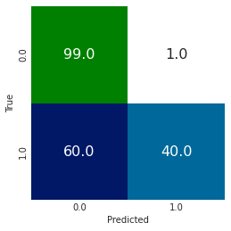

```python
plotCM(y_test,y_pred35, normalize=True)
```

##### Exactitud del modelo

Notemos que la exactitud del modelo con respecto al test es del 98%, lo cual es muy bueno y es mucho mejor de lo que dio en el modelo con la base de datos balanceada.

```python
print("Exactitud del test es: {:.2f}".format( accuracy_score(y_test,y_pred35) ))
```

```
Exactitud del test es: 0.98
```

### Arboles de decisión

Realizaremos un arbol de decisión con los datos desbalanceados

```python
clf2 = DecisionTreeClassifier(max_depth=None, max_leaf_nodes=6, max_features=3)
clf3 = clf2.fit(X_train,y_train)
```

```python
dot_data = tree.export_graphviz(clf2, out_file=None,
                        feature_names=X_train.columns,
                        class_names= "Biopsy",
                         filled=True, rounded=True,
                         special_characters=True)
graph = graphviz.Source(dot_data)
graph
```

[figure not shown]

### Matriz de confusión

```python
y_pred36 = clf2.predict(X_test)
plotCM(y_test,y_pred36, normalize=True)
```

[output not shown]

##### Exactitud del modelo

Notemos que la exactitud del modelo con respecto al test es del 98%, lo cual es muy bueno y es mucho mejor de lo que dio en el modelo con la base de datos balanceada.

```python
print("Exactitud del test es: {:.2f}".format( accuracy_score(y_test,y_pred36) ))
```

```
Exactitud del test es: 0.98
```

### Guassiano Mixture

Para el Gaussiano Mixture en la base de datos desbalanceada tenemos que los mejores parametros son con la covarianza de tipo full y 5 componentes.

```python
scale = StandardScaler().fit(X_train)
gmm = GaussianMixture( random_state=2)
pipeline61 = Pipeline(steps=[('gmm', gmm)])
param_grid = {
    'gmm__n_components': [1,2,3,4,5],
    'gmm__covariance_type': ('full', 'tied', 'diag', 'spherical')
}
search61 = GridSearchCV(pipeline61, param_grid,scoring='adjusted_rand_score',cv =cv)
search61_fit = search61.fit(X_train,y_train)
```

```python
print(search61.best_params_)
print("La metrica Ari con Train(Score): {:.2f}".format(search61.best_score_))
```

```
{'gmm__covariance_type': 'full', 'gmm__n_components': 5}
La metrica Ari con Train(Score): 0.20
```

### Metrica (ARI)

Tenemos que es una metrica entre -1 y 1, donde si se tiene un Ari muy cercano a 0 son etiquetas aleatorias y si es cercano a 1 tenemos que coinciden perfectamente.

```python
y_pred61 = search61.predict(X_test)
metrica_ari = adjusted_rand_score(y_test,y_pred61)
print("Metrica ari: {:.2f}".format( metrica_ari ))
```

```
Metrica ari: 0.01
```

La metrica ari para el conjunto de prueba es de casi 0 lo que significa que las clases estan completamente divididos en los clustering, lo cual puede llegar a ser incompleto.

### Metrica Fowlkes_ Mallowas

según esta metrica tenemos que los valores van entre 0 y 1. Donde entre más cercano hay una buena similitud entre los clustering.

```python
metrica_fow = fowlkes_mallows_score(y_test,y_pred61)
print("Metrica fowlkes_mallows : {:.2f}".format( metrica_fow ))
```

```
Metrica fowlkes_mallows : 0.64
```

Obtuvimos según esta metrica que hay una buena similitud entre los cluster ya que es del 0.64, sin embargo no es tan buena como la de la base de datos balanceada.

# Conclusiones

- La base de datos presentó inicialmente variables NaN en los cuales se realizó una imputación tomando la mediana para evitar valores decimales en las variables categoricas. Además se encontraba muy desbalanceada en su variable respuesta Biopsia, por lo cual realizamos un SMOTE para balancear la base de datos, logrando que la clase minoritaria (Biopsia = 1) supliera al menos el 35% de la clase mayoritaria (Biopsia = 0).
- Realizamos reducción de la dimensión utilizando PCA, KPCA, ICA y T-Sne, con 2 componentes. En PCA, ICA y T-Sne no era muy notoria la división de las categorías en la variable respuesta, en T-Sne no se logró encontrar la perplejidad adecuada para realizar una división correcta de los datos, debido a que al tomar un valor muy grande los datos se juntaban mas pero si era muy pequeño se dispersaban tanto que no marcaban una división. Por otra parte, con KPCA si logramos apreciar una buena división de las categorías, de manera que observamos claramente los distintos componentes.
- Realizamos diferentes pipelines con PCA, KPCA e ICA utilizando los datos balanceados y no balanceados. Debido a que T-Sne no funcionaba para realizar pipeline lo evitamos. El pipeline en general nos permite ver cual es el mejor modelo de clasificación, utilizando validación cruzada con k-folds, entre regresión logística con y sin regularización, análisis discriminante, Naive Bayes, KNN y RandomForest.

**Resultados de pipeline con la base de datos balanceada**

- **PCA**: Utilizamos un arreglo con distinto número de componentes de 2 a 20 en donde queremos ver cual es el mejor número de componentes y el mejor modelo. Obtuvimos como resultado que el mejor de los modelos es RandomForest con un número de componentes de 15 y una exactitud del 95% para el conjunto de entrenamiento. Al evaluarlo con el conjunto test obtuvimos una exactitud del 99%.
- **KPCA**: Utilizamos un vector con un número de componentes de 2 a 6 en donde queremos ver cual es el mejor número de componentes y el mejor modelo. Obtuvimos como resultado que el mejor de los modelos es RandomForest con un número de componentes de 6 y una exactitud del 84% para el conjunto de entrenamiento. Al evaluarlo con el conjunto test obtuvimos una exactitud del 93%.
- **ICA**: Utilizamos un vector con un número de componentes de 1 a 19 en donde queremos ver cual es el mejor número de componentes, la mejor función y el mejor modelo. Obtuvimos como resultado que el mejor de los modelos es RandomForest, con un número de componentes de 13, la función exponencial y una exactitud del 95% para el conjunto de entrenamiento. Al evaluarlo con el conjunto test obtuvimos una exactitud del 97%.

Comparando la exactitud de los modelos anteriores, concluimos que el mejor modelo en la base de datos balanceada fue el de PCA, ya que tuvo una exactitud del 99%, superior a las demas.

**Resultados de pipeline con la base de datos desbalanceada**

- De acuerdo con los anteriores resultados podemos concluir que en este caso fue mejor utilizar la base de datos desbalanceada, ya que en todas las reducciones de dimensión nos mostró iguales o mejores resultados en la exactitud de cada uno.

Realizamos regresión logística con y sin regularización, análisis discriminante, Naive Bayes, Gaussiano Mixture, KNN y árboles de decisión.

**Resultados sin reducción de dimensiones con base de datos balanceada**

- **Regresión logística**: Los resultados obtenidos con la regresión logística sin regularización para la exactitud utilizando el test fueron del 97%. Utilizando Ridge también obtuvimos 97% e igualmente con LASSO. Por lo cual los 3 modelos nos mostraron los mismos resultados en regresión logística.
- **Analisis discriminante**: Los resultados obtenidos con análisis discriminante tuvieron una exactitud del 97%, por lo cual es igual de bueno que la regresión logística.
- **Naive Bayes**: Obtuvo una exactitud del 97.57% por lo cual notamos que es mayor a los anteriore.
- **KNN**: Obtuvo una exactitud del 97%.
- **Alboles de decision**: Obtuvieron una exactitud del 96%, inferior a los anteriores.
- De acuerdo a los anteriores resultados podemos concluir que el mejor modelo fue el de Naive Bayes con la exactitud de 97.57%.

**Resultados sin reduccion de dimensiones con base de datos desbalanceada**

**GLM balanceado**: Las variables que presentaron alta multicolinealidad con las demás son: Dx, la interaccion de Smokes con Age, STDs_number, STDs_vaginal_condylomatosis, STDs_syphilis, STDs_genital_herpes, STDs_pelvic_inflammatory_disease y STDs_HIV, sin embargo también notamos que las STDs no fueron tan relevantes al momento de predecir la Biopsia. También obtuvimos que Hinselman y Schiler fueron las pruebas más relevantes en los resultados de la biopsia. El GLM balanceado obtuvo un accuracy del 41%.

Podemos notar que en este caso el GLM balanceado fue el mejor ya que obtuvo un accuracy más alto, sin embargo no es bueno ya que sólo llega al 41%.

**Gaussiam Mixto balanceado**: Para este modelo utilizamos un pipeline con validación cruzada para determinar el mejor número de componentes entre 1 a 5 y el mejor tipo de covarianza, utilizando la métrica ARI. Obtuvimos como resultado que el mejor tipo de covarianza fue la diagonal con el número de componentes 3, la métrica ARI nos dió 0.25 lo que tiene un clustering un poco similar pero no llega a ser perfecto. Finalmente probamos la métrica ARI con el conjunto test y nos dió un valor muy cercano a 0, por lo cual concluimos que la división de las clases fue incompleta. Al probar la métrica fowlkes-mallowas obtuvimos como resultado 0.74 la cual fue buena y concluimos que existe una similitud entre los clustering aunque no llega a ser perfecta.

**Gaussiam Mixto desbalanceado**: Para este modelo utilizamos un pipeline con validación cruzada para determinar el mejor número de componentes entre 1 a 5 y el mejor tipo de covarianza, utilizando la métrica ARI. Obtuvimos como resultado que el mejor tipo de covarianza fue la full con el número de componentes 5, la métrica ARI nos dió 0.20 lo que tiene un clustering un poco similar pero no llega a ser perfecto. Finalmente probamos la métrica ARI con el conjunto test y nos dió un valor muy cercano a 0, por lo cual concluimos que la división de las clases fue incompleta. Al probar la métrica fowlkes-mallowas obtuvimos como resultado 0.64 la cual fue buena y concluimos que existe una similitud entre los clustering aunque no llega a ser perfecta.

De acuerdo a los anteriores resultados podemos concluir que el mejor fue el gaussiano mixto balanceado.

- En general los resultados dados por la base de datos desbalanceada fueron mucho mejores que la balanceada debido a que se toman unos valores más exactos sin tener que realizar una generación de nuevos valores que estén clasificados como la clase minoritaria. Lo ideal es que en ambas categorías este equilibrada la cantidad o que al menos se cubra un porcentaje para lograr una mejor clasificación en todos los modelos.

# Bibliografía

- scikit-learn.org
- statmodels.org

[figure not shown]

Created in Deepnote